# Occupational Routine-Intensity and the Costs of Job Loss: Evidence from Mass Layoffs

Converted from PDF `Blien-RoutineIntensityJobLoss-2019-IZA.pdf` · 40 pages · anchors: page `#pN`, block `#pN-bK`

Page 1

[figure not shown]

NOTE: figure/graphic rendered as an image from the PDF; its content is not machine-readable text. Caption (if any) follows as the next block.

**text found inside the figure**

DISCUSSION PAPER SERIES

IZA DP No. 12851

Uwe Blien Wolfgang Dauth Duncan Roth

**Occupational Routine-Intensity and the Costs of Job Loss: Evidence from Mass Layoffs**

DECEMBER 2019

Page 2

Any opinions expressed in this paper are those of the author(s) and not those of IZA. Research published in this series may include views on policy, but IZA takes no institutional policy positions. The IZA research network is committed to the IZA Guiding Principles of Research Integrity. The IZA Institute of Labor Economics is an independent economic research institute that conducts research in labor economics and offers evidence-based policy advice on labor market issues. Supported by the Deutsche Post Foundation, IZA runs the world’s largest network of economists, whose research aims to provide answers to the global labor market challenges of our time. Our key objective is to build bridges between academic research, policymakers and society. IZA Discussion Papers often represent preliminary work and are circulated to encourage discussion. Citation of such a paper should account for its provisional character. A revised version may be available directly from the author.

[output not shown]

NOTE: table converted from PDF layout to HTML text; cell boundaries are reconstructed. See PDF if exact alignment matters.

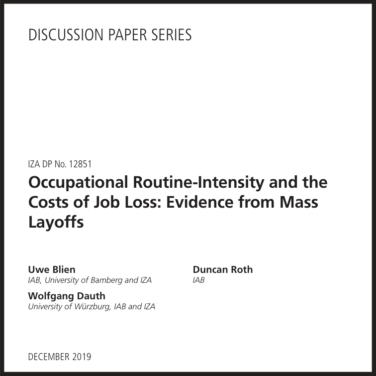

NOTE: figure/graphic rendered as an image from the PDF; its content is not machine-readable text. Caption (if any) follows as the next block.

**text found inside the figure**

DISCUSSION PAPER SERIES

IZA DP No. 12851 **Occupational Routine-Intensity and the Costs of Job Loss: Evidence from Mass Layoffs**

DECEMBER 2019

**Uwe Blien** *IAB, University of Bamberg and IZA*

**Wolfgang Dauth** *University of Würzburg, IAB and IZA*

**Duncan Roth** *IAB*

ISSN: 2365-9793

Page 3

## ABSTRACT

IZA DP No. 12851 DECEMBER 2019

## **Occupational Routine-Intensity and the Costs of Job Loss: Evidence from Mass Layoffs**

This paper analyses how differences in the degree of occupational routine-intensity affect

the costs of job loss. We use worker-level data on mass layoffs in Germany between 1980

and 2010 and provide causal evidence that workers who used to be employed in more

routine-intensive occupations suffer larger and more persistent earnings losses after the

mass layoff. Furthermore, we are able to show that, at least initially, earnings losses are

primarily due to a reduction in the number of days in employment, suggesting that routine-

intensive workers face considerable frictions in the adjustment to job loss. Conditional on

finding a new job, routine-intensive workers are more likely to change their occupations

but end up systematically in the lower end of their new occupation’s wage distribution.

**JEL Classification:** J24, J63 O33

**Keywords:** routine-replacing technological change, routine-intensity, labour market biographies, mass layoffs, Germany, difference-in-differences

**Corresponding author:** Uwe Blien Institute for Employment Research (IAB) Regensburger Straße 104 90478 Nürnberg Germany

Email: uwe.blien@iab.de

Page 4

2

1 Introduction and background Technological progress has often been the source of concerns about potentially negative effects on employment. On the one hand, these concerns refer to the general level of employment which are commonly discussed under the label of ‘technological unemployment’ (the term is often attributed to Keynes, 2010, though it is much older). On the other hand, certain groups of workers appear to be at a larger risk of job loss than others. As modern computer controlled technology is particularly suited to executing algorithms, i.e. repeatedly following a fixed set of rules, it is potentially able to substitute workers whose jobs primarily consist of performing routine tasks (Autor et al., 2003; Spitz‐Oener, 2006). ‘Routine-replacing technological change’ has since been established as a well-documented stylized fact (Autor and Salomons, 2017; Biagi et al., 2018). From an aggregate perspective, this form of technical progress is often associated with a polarisation of the labour market since routineintensive occupations are mostly located in the middle of the wage distribution in many countries (e.g. Autor and Dorn, 2013; Goos et al., 2014; Fonseca et al., 2018).

Recent papers have focused on outcomes at the individual level, thereby addressing the question how technological progress has affected the careers of routine workers. In our paper, we extend this research agenda by addressing the frictions that these workers meet, especially in the form of involuntary unemployment. We compare the fates of workers in jobs with different degrees of routineintensity. We focus on the population of workers displaced during mass layoffs in their respective firms. All those workers experience the same exogenous shock to their employment biography and are forced to adjust to this shock by searching for a new job. However, the resulting decline in employment and wages is worse for workers in more routine-intensive occupations. This mirrors the fact that demand for routine labour is shrinking, while occupations that involve human interaction and complex, time varying, and creative tasks are complements to new technologies. With this paper, we intend to provide new insights on the impact of modern technologies on individual labour market outcomes such as employment and earnings perspectives.

The individual perspective entails several crucial selection issues. First, it is ex ante unclear if and how technological change causes job mobility because incumbent workers may be shielded from the effects of technological change. Even if new technologies could potentially replace human labour, institutions might prevent employers from actually using this technology at will. Job protection laws make it costly for employers to replace workers with machines. Depending on how easily they can be re-trained, incumbent workers are either assigned to a different function or kept at their original job. Especially in European countries, this is amplified by the tendency of labour unions and work councils to protect insiders from labour-saving technological change (Lommerud and Straume, 2011). This creates an insider/outsider distinction on how technological change will affect workers. We therefore focus on a group of workers that is particularly vulnerable: Workers who lost their job during a mass layoff. Those workers face an exogenous shock to their employment biography and previous research has shown that this causes a large and persistent earnings loss (Jacobson et al., 1993; Davis and von Wachter, 2011). We analyse if the magnitude of this loss is systematically related to the routine-intensity of the occupation performed before the layoff.<sup>1</sup>

The second major concern is that workers select into occupations for reasons that are potentially correlated with subsequent labour market outcomes. If routine-intensive jobs require fewer formal skills and offer smaller wages than non-routine jobs, workers with lower (observed and unobserved) skills select into those jobs. It is therefore not clear how much of the difference in labour market

1 In Germany, larger firms that do not lay off their entire workforce must develop a ‘social plan’ for a mass layoff, which essentially sorts workers according to their tenure and not according to their skills. The probability of job loss during a mass layoff is therefore unlikely to be correlated with the routine-intensity of the previous job.

Page 5

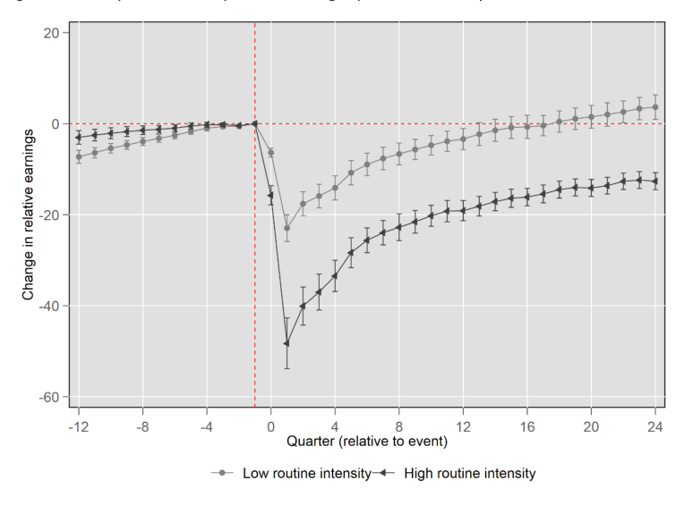

NOTE: figure/graphic rendered as an image from the PDF; its content is not machine-readable text. Caption (if any) follows as the next block.

3

outcomes between routine and non-routine workers can actually be attributed to routine-replacing technological change and how much to selection on observable or unobservable skills.

Figure 1: The impact of mass layoffs on earnings by routine-intensity

*Notes: Estimates of time-to-event dummies from regressions of relative earnings that also controls for individual fixed effects and quarter dummies. Coefficient estimates of the time-to-event dummies are relative to quarter directly preceding the mass layoff. Vertical bars indicate the estimated 95% confidence interval based on standard errors that are clustered at the level of 83 occupations. ‘Low routine-intensity’ uses observations of individuals who during the first quarter before the mass layoff are employed in occupations that fall into the bottom quartile of the distribution of routine-intensity. ‘High routine-intensity’ refers to the top quartile of the distribution of routine-intensity. Sources: IEB, BIBB-IAB employee survey.*

To address those concerns, we modify an event study design in the spirit of Jacobson et al. (1993) and Davis et al. (2011) to analyse if the routine-intensity of a worker’s previous job affects the chances to subsequently return to the previous earnings level. Figure 1 provides an outlook on the idea underlying our empirical approach. It shows the coefficient estimates of dummy variables indicating the number of quarters before/after displacement from a panel-data regression of earnings (normalized by prelayoff earnings) on worker-fixed effects and time fixed effects, which is the standard procedure in the literature on mass layoffs. We estimate this model separately for individuals who used to be employed in the top and the bottom quartile of the routine-intensity distribution before the mass layoff. The earnings profiles show that the relative earnings drop is considerably larger for workers from routineintensive occupations both, immediately after the displacement and persistently over the next six years. However, one might object that workers in occupations at the extremes of the distribution of routine-intensity are not comparable in many ways. In our main specification, we therefore interact the time-to-event indicators with a continuous measure of routine-intensity. This means that our estimates for the impact of routine-intensity on the costs of displacement are tightly identified by small differences in routine-intensity of otherwise similar workers. However, one remarkable finding of Figure 1 is that the earnings profiles prior to displacement are extremely similar for workers in both

Page 6

4

groups, despite the arguably different nature of those occupations. Our results indicate that on average mass layoffs severely and persistently reduce earnings, but that this effect becomes more pronounced as the degree of routine-intensity increases. This stems mostly from an additional negative effect of routine-intensity on the number of days in employment after the layoff, while the additional negative effect on wages is significant but more modest. Moreover, we find that the initial degree of routine-intensity increases the probability of switching to a different occupation and that such workers earn below-average wages in their new occupations. A plausible explanation of these findings is that technological progress has reduced the demand for routine-intensive labour, which increases the costs of adjusting to job loss for workers initially employed in such occupations.

Our paper is most closely related to other studies that assess the consequences of technical progress for individual workers. Cortes (2016) develops a general equilibrium model that predicts a distinct pattern of selective mobility out of declining routine occupations. This is in line with individual data from the US, where higher skilled routine workers move to non-routine cognitive jobs and low skilled routine workers move to non-routine manual jobs. In a paper by Cortes et al. (2017) the authors develop a model similar to the one by Autor and Dorn (2013). In this model workers decide between employment and non-employment and between routine and manual work. With higher levels of automation, the demand for routine workers decreases and so does their wage. In the end, workers switch to manual jobs or drop out of employment. The authors conclude that this corresponds to their empirical findings. One difference to our paper is that in their framework unemployment can only be voluntarily, whereas we include involuntary unemployment too. This is similar to the empirical analysis by Bachmann et al. (2019), who study the adjustment of German workers to routine‐biased technological change and find that more routine-intensive workers are more likely to lose their jobs.

A related literature studies the cost of occupational mobility. While changing jobs is generally assumed to entail the loss of specific human capital, Gathmann and Schönberg (2010) argue that human capital is in fact task-specific. This implies that job mobility to an occupation that requires a similar set of tasks does not necessarily lead to wage losses. This is corroborated by recent findings of Robinson (2018), who shows that displaced workers are particularly at risk of losing this specific human capital because they are often forced to switch to different occupations that either use different skills compared to the previous occupation or the same skills but at a lower intensity. In the context of our paper, this means that workers in routine-intensive occupations have a twofold problem: They are exogenously forced to find a new job while their old occupation is eroding due to routine-replacing technological change. We therefore expect the costs of displacement increase with an occupation’s routine-intensity. Cortes and Gallipoli (2018) show that task-specific costs that arise, for example, when switching out of routine-intensive jobs, account for around 15 percent of the total switching costs. This is also in line with the recent work by Edin et al. (2019), who find that workers in declining occupations face severe income and employment losses, which they explain by an increased need for retraining as well as increased probability of unemployment. The magnitude of these effects does not appear to depend on the specific cause of the occupational decline. We, by contrast, focus on technological change as, arguably, the most important systematic driver of occupational decline.

While we emphasise the role of technological progress as the driving force behind the developments described in this paper, we acknowledge that other factors may also be relevant in explaining the fact that the costs of job loss are larger among routine-intensive workers. Autor et al. (2015) assess the relative importance of technological progress and international trade and find that those sectors that are most affected by imports also employ a relatively high share of routine labour. Moreover, if routine tasks can also be performed abroad, firms may have an incentive to off-shore parts of their employment (Hummels et al., 2018; Oldenski, 2014).

Page 7

5

Our paper differs from others by explicitly including unemployment in the research design. Unemployment can be involuntary in the sense that unemployed workers would be ready to accept new jobs at the current wage on the market. However, due to the shrinking demand (for routine work) they are not able to find one. Often they have to switch to other occupations. However, there are barriers according to the qualifications needed to perform the new occupation. For routine workers many frictions are important. For them, it is not easy to take find employment in occupations with a lower degree of routinisation. The qualifications they acquired are often obsolete due to technological progress. In our paper, we allow for the effects of search frictions. We therefore complement other papers, which assume that workers can move easily into non-routine occupations. Like those papers, we also look at the wage reaction, which is associated with the external shock.

The structure of the remainder of the paper is as follows. Besides introducing the dataset, Section 2 explains how we identify workers who experienced mass layoff and compares the characteristics of these workers with workers not involved in a mass layoff. Moreover, we discuss our measure of occupational routine-intensity. The empirical model and the identification of the additional costs due to differences in routine-intensity are the topics of Section 3. The results of our analysis are presented in Section 4. After showing the estimated average impact of mass layoffs on earnings, we discuss how these effects differ depending on the initial degree of routine-intensity and decompose these effects to identify the underlying mechanisms. In addition, we analyse the transitions into different forms of employment after the mass layoff as well as effect heterogeneity across different groups of workers. Section 5 concludes.

2 Data and variables The purpose of this section is to describe the dataset and the main variables of the empirical analysis. The first subsection documents how we identify the establishments that experienced mass layoff and how we match information on the workers that were employed at those establishments before the mass layoff. We then provide information about establishment and worker characteristics and compare them with a random sample of workers who were not involved in a mass layoff. The second subsection introduces our measure of occupational routine-intensity.

2.1 Identification of mass layoffs Constructing a dataset of workers who experienced mass layoff first requires identifying those establishments in which such an event occurred. To this end, we follow established contributions to the mass layoff literature (in particular, Davis and von Wachter, 2011). We use the full sample of all plants in Germany observed on June 30 of each year between 1978 and 2014 provided by the IAB Establishment History Panel (BHP). We identify all plants with at least 50 employees on June 30 of one year that contracted by between 30 and 100 percent by June 30 in the next year but had a stable workforce before this incident and did not recover in the years after. We furthermore employ the heuristic of Hethey-Maier and Schmieder (2010) and drop all cases where a significant share of former employees switch to the same new establishment, raising the suspicion of being actually due to the restructuring of plants within the same firm rather than an actual mass layoff.<sup>2</sup>

In the next step, we draw the full labour market biographies of all workers that were employed in one of the previously identified plants at the onset of a mass layoff but lost their job during the following year. This information comes from the Integrated Employment Biographies (IEB, version 13.00.01), which contain information on all labour market participants in Germany (except for civil servants and the self-employed). Based on this data we construct an individual-level panel data set at quarterly

2 See section A1 in the supplementary Online Appendix for a detailed description on how we identify mass layoffs.

Page 8

6

frequency, containing the number of days in employment as well as total earnings per quarter. Each worker in the dataset is observed for 12 quarters before and for up to 24 quarters after the mass layoff.

Table 1: Worker characteristics

[output not shown]

NOTE: table converted from PDF layout to HTML text; cell boundaries are reconstructed. See PDF if exact alignment matters.

(30.32) (30.28) (32.66) (30.70) (33.14) (31.21) (31.61) (30.75) Services 33.43 37.69 39.00 42.93 45.90 48.79 39.41 43.37 (47.18) (48.46) (48.78) (49.50) (49.83) (49.99) (48.87) (49.56) Observations 86,310 172,620 125,942 251,884 100,382 200,764 312,634 625,268 *Notes: The table shows the share of workers in percentage points as well as the corresponding standard deviations for various individual-level characteristics. The columns ‘ML’ show the values for those workers who experienced a mass layoff (measured at the quarter directly preceding the mass layoff). The columns ‘Comparison’ show the values for a randomly chosen group of workers who did not experience mass layoff, but who satisfy the same conditions as the workers in the mass layoff sample (e.g. age and minimum level of tenure). Source: IEB.*

We restrict the sample to those individuals who were aged between 25 and 50 at the time of the mass layoff and who had been in regular full-time employment for the three years before the event. These restrictions are imposed because it is unclear how workers are affected by a mass layoff if they are only loosely attached to a plant in the first place or if they are close to retirement age. We therefore focus on individuals who, in the absence of such an event, would be expected to continue working at the establishment. As mass layoff establishments are identified by comparing the development of employment levels over a one-year period, all workers are included in the sample who were employed

Page 9

7

at such an establishment during that period. This implies that even if some workers left in anticipation of the mass layoff, they would still be included in the sample as long as their departure fell into this one-year window.

The focus on individuals who were displaced during a mass layoff might raise the objection that they are not representative of the full population of employees in Germany. We therefore compare the workers in our mass layoff sample to a sample of randomly drawn workers who satisfy the same conditions with respect to age and tenure as the mass layoff sample.<sup>3</sup> Moreover, we draw the individuals from the comparison group in a way that the establishment-level characteristics – sector structure, establishment size, location in East/West Germany – are identical to those of the mass layoff sample (see Table A2). Table 1 shows that over the whole period as well as in each of the three decades average quarterly earnings are comparable in size. The number of days in employment per quarter is very similar in both samples. In terms of the outcome variables there appears to be no evidence that the workers who experienced a mass layoff represent a negatively selected sample. Since mass layoffs occur disproportionally often in the manufacturing sector, the share of females is smaller, the fraction of foreigners is larger, and the education levels are lower among those who experienced a mass layoff.

2.2 Construction of the routine-intensity measure The objective of this paper is to assess whether the degree to which an employee’s occupation contains routine components affects how workers can adjust to unexpected job loss against the background of a changing labour market in which routine labour input can increasingly be substituted by machines. We therefore require a measure of occupational routine-intensity. Related studies from the US typically use information on the task contents of occupations provided by the Dictionary of Occupational Titles (DOT) or the Occupational Information Network (O*NET) to construct corresponding measures (see Autor, 2013 for a description of these datasets).<sup>4</sup>

Instead, we use the BIBB-IAB employee survey (*BIBB-IAB-Erwerbstätigenbefragung*), which has been conducted by the Federal Institute for Vocational Education (BIBB) and the Institute for Employment Research (IAB) in the years 1985, 1991 and 1999. These datasets contain detailed information on various job characteristics and cover between 25,000 (1985 wave) and 35,000 (1991, 1999 waves) individuals. This dataset has already been extensively used by previous German studies to construct measures that reflect the share of routine tasks in an occupation (Spitz‐Oener, 2006; Antonczyk et al., 2009; Black and Spitz-Oener, 2010). This approach, however, hinges on correctly classifying the tasks contained in the survey as constituting routine or non-routine tasks. Unfortunately, those questions differ strongly between the different survey waves. For example, the 1985 wave contains five tasks that can be classified as routine manual. This number then increases to eight in the 1991 wave, before falling back to two in the last survey. This makes it difficult to construct a time-consistent measure for an occupation’s routine-intensity.

We believe it is more straightforward to measure the potential substitutability by machines by focussing on those parts of the production process where machines have a comparative advantage over human labour. As stated by Autor et al. (2003), machines ‘rapidly and accurately perform repetitive tasks that are deterministically specified by stored instruction (programs) that designate unambiguously what actions the machine will perform at each contingency to achieve the desired

3 For each combination of decade, sector, plant size, and East/West-location we draw twice the number of observations compared to the mass layoff sample. 4 The German equivalent to O*NET is called BERUFENET. Since it is only available from 2011 onwards, it is possible that it only represents the current prevalence of routine components within an occupation, which might actually be the outcome of technological progress and not the situation when people in our analysis selected into occupations or at the time of displacement.

Page 10

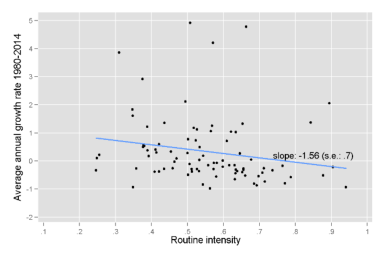

NOTE: figure/graphic rendered as an image from the PDF; its content is not machine-readable text. Caption (if any) follows as the next block.

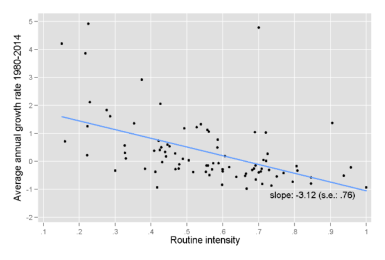

NOTE: figure/graphic rendered as an image from the PDF; its content is not machine-readable text. Caption (if any) follows as the next block.

8

result.’ To capture the notion that machines are effective at repeatedly executing pre-described procedures we make use of the two following items that appear in every survey wave:

*1) Are the contents of your job minutely described by the employer? 2) Does the job sequence repeat itself regularly?*

Specifically, we define occupational routine-intensity as the weighted share of workers reporting both items to be the case *‘almost always’* for each of the 83 occupations (*Berufsgruppen*) of the 1988 occupational classification scheme (*Klassifikation der Berufe 1988*).<sup>5</sup> Specifically, we assign each worker the routine-intensity of the occupation performed during the quarter directly preceding the mass layoff. Therefore, we use the measure derived from the 1985 survey for individuals who experienced mass layoff during the decade 1980-89. Analogously, we use the 1991 and 1999 survey for mass layoffs that occurred during the period 1990-99 and 2000-10, respectively. To ensure comparability with other studies, we also replicated the more traditional routine-intensity measure that is based on the share of tasks, which has been used by the previous literature.<sup>6</sup>

Figure 2: Correlation of occupational employment growth and routine-intensity

Panel A: unconditional Panel B: conditional

*Notes: Panel A shows the correlation of employment growth between 1980 and 2014 and the routine-intensity of the 83 German 2-digit occupations. In Panel B, both variables have been purged of the occupation’s average wage, age, and shares of women and college graduates in 1980. The solid line represents the slope of the regression coefficient. Sources: IEB, BIBB- IAB employee survey.*

Table A3 in the online appendix reports the routine-intensity of each occupation in each survey year. Manufacturing occupations turn out to be particularly routine-intensive: out of the 25 occupations with the highest degree of routine-intensity in each survey year, 21 can be associated with manufacturing. By contrast, technical occupations such as *engineers* or *chemists, physicists and mathematicians* as well as other service occupations such as *teachers* or *journalists, interpreters, librarians* or *management consultants, organisers, chartered accountants* represent large occupations that consistently rank among the bottom 25 in terms of routine-intensity. To see if our definition of routine-intensity is in line with routine-replacing technological change, we use the complete 30% sample of our individual data to plot the average annual employment growth rate of each occupation over the period 1980-2014 against its routine-intensity in 1985. The left panel of Figure 2 shows a clear

5 We restrict the sample to male and female employees working at least 35 hours per week. Sampling weights are used in the construction of the routine intensity measure. The remaining answer options are *‘often’*, *‘occasionally’*, *‘rarely’* and *‘hardly anytime’*. Table A4 shows that our findings are robust to using the share of workers reporting both items to be the case either *‘almost always’* or *‘often’*. We exclude the group *‘Other occupations’* (*Andere Arbeitskräfte*). 6 We show in section 4.5 that comparable results are obtained when using the task-based measure of routine intensity.

Page 11

9

Analogous to Table 1, we show descriptive statistics of the routine-intensity measure for individuals who experienced a mass layoff and compare them with the corresponding values for a randomly chosen group of workers who did not experience such an event. Table 2 shows that average routineintensity has a similar size in both groups in each decade and that it decreases over time. We conclude, that, as was the case for the three outcome variables, the employees in the mass layoff sample do not represent a negatively selected sample characterised by unusually high levels of routine-intensity.

Table 2: Worker characteristics (routine-intensity)

[output not shown]

NOTE: table converted from PDF layout to HTML text; cell boundaries are reconstructed. See PDF if exact alignment matters.

(11.63) (11.29) (12.43) (11.70) (11.31) (11.42) (11.88) (11.50) Observations 86,310 172,620 125,942 251,884 100,382 200,764 312,634 625,268 *Notes: The table shows mean values of routine-intensity as well as the corresponding standard deviations. The columns ‘ML’ show the values for those workers who experienced a mass layoff (measured at the quarter directly preceding the mass layoff). The columns ‘Comparison’ show the values for a randomly chosen group of workers who did not experience mass layoff, but who satisfy the same conditions as the workers in the mass layoff sample (e.g. age and minimum level of tenure). Sources: IEB, BIBB-IAB employee survey.*

3 Empirical strategy In a first step, we estimate the effects that a mass layoff has on individual labour market outcomes. For this purpose we employ an event-study approach, which is commonly used in the mass layoff literature (see Schmidheiny and Siegloch, 2019 for a discussion of event-study approaches). Specifically, we use the following difference-in-differences model:

𝑦𝑖𝑡= ∑ 𝛿𝑘

**equation / math rendering (image)**

NOTE: contains mathematical notation; text above is the PDF text layer and symbols may be mis-extracted. Image shows the original.

24

**equation / math rendering (image)**

NOTE: contains mathematical notation; text above is the PDF text layer and symbols may be mis-extracted. Image shows the original.

𝑘=−12,𝑘≠−1

**equation / math rendering (image)**

NOTE: contains mathematical notation; text above is the PDF text layer and symbols may be mis-extracted. Image shows the original.

𝐼(𝑡= 𝑡<sup>′</sup> + 𝑘) + 𝜑𝑡+ 𝛼𝑖+ 𝑢𝑖𝑡 (1)

**equation / math rendering (image)**

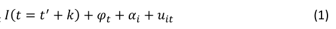

NOTE: contains mathematical notation; text above is the PDF text layer and symbols may be mis-extracted. Image shows the original.

The dependent variable *yit* represents an outcome variable of individual *i* during quarter *t:* quarterly earnings, number of days in employment per quarter, average daily wage. While these outcomes are often measured in logarithmic form, doing so would cause problems with quarters where an individual is not employed and hence receives zero earnings, possibly endogenously due to difficulties in adjusting to the layoff. Instead we measure each outcome as a fraction of the individual’s average outcome during the 12 quarters preceding the mass layoff, which also allows for an interpretation in relative terms.

*I(t = t’ + k)* stands for a set of time-to-event dummies which indicate the timing of quarter *t* relative to the quarter of the mass layoff *t’*. The baseline period is the quarter directly preceding the mass layoff (*k = -1*). The coefficients *δk* provide information about the change in the value of the outcome between quarter *t* and the quarter of the mass layoff. They therefore shed light on the average development of outcomes following the mass layoff as well as on the trends prior to the event. In addition, the model includes a set of quarter fixed effects, which account for unobserved macroeconomic effects. *αi* represent individual fixed effects that allow us to control for unobserved, time-invariant worker characteristics and uit is a random error term.

One might also want to control for individual characteristics of workers and the characteristics of their employers, all measured in the quarter prior to the event. However, these variables would all be perfectly multicollinear with the individual-specific fixed effects and are therefore already accounted

Page 12

10

for. We nonetheless show that the results from an alternative model in which the fixed effects are replaced by additional individual-level and establishment-level variables that are measured at the time of the mass layoff are similar to the results presented in the following section.

In order to assess how the effect of job loss varies with the prevalence of routine-intensity in an individual’s occupation, we extend the model in Equation (1) by including interactions between our measure of routine-intensity in occupation *o* that was held by individual *i* in the quarter before the mass layoff, *RIo*, and the time-to-event dummies:

𝑦𝑖𝑜𝑡= ∑ [𝛾𝑘𝑅𝐼𝑜× 𝐼(𝑡= 𝑡<sup>′</sup> + 𝑘) + ∑ {𝛿𝑘

**equation / math rendering (image)**

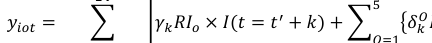

NOTE: contains mathematical notation; text above is the PDF text layer and symbols may be mis-extracted. Image shows the original.

𝑂𝐼(𝑜∈𝑂) × 𝐼(𝑡= 𝑡′ + 𝑘)} 5

**equation / math rendering (image)**

NOTE: contains mathematical notation; text above is the PDF text layer and symbols may be mis-extracted. Image shows the original.

𝑂=1

**equation / math rendering (image)**

NOTE: contains mathematical notation; text above is the PDF text layer and symbols may be mis-extracted. Image shows the original.

]

**equation / math rendering (image)**

NOTE: contains mathematical notation; text above is the PDF text layer and symbols may be mis-extracted. Image shows the original.

24

**equation / math rendering (image)**

NOTE: contains mathematical notation; text above is the PDF text layer and symbols may be mis-extracted. Image shows the original.

𝑘=−12;𝑘≠−1

**equation / math rendering (image)**

NOTE: contains mathematical notation; text above is the PDF text layer and symbols may be mis-extracted. Image shows the original.

+ 𝜓𝑡+ 𝜂𝑖+ 𝑣𝑖𝑜𝑡 (2)

**equation / math rendering (image)**

NOTE: contains mathematical notation; text above is the PDF text layer and symbols may be mis-extracted. Image shows the original.

The coefficients *γk* show how a difference in occupational routine-intensity by one percentage point affects the magnitude of the difference in the outcomes between the quarter of the mass layoff (*k = - 1*) and the quarter *k*. The corresponding coefficient estimates therefore provide the basis for evaluating whether the effects of job loss are larger among workers in more routine-intensive occupations and whether these effects are persistent.

Our identification strategy builds on comparing the long run effects of a layoff for otherwise identical workers who held similar jobs with routine-intensities that differ only by a small extent. Including individual fixed effects means that individual characteristics are held constant in the cross section. In addition, we want to ensure that each coefficient 𝛾𝑘 is identified by marginal changes in routineintensity within groups of otherwise similar occupations and not across very different occupations over the entire distribution of the measure of routine-intensity. To this end, we let the coefficients of the time-to-event dummies 𝛿𝑘

𝑂 vary over the 5 aggregate occupation groups (*Berufsbereiche* in the 1988 German occupational classification scheme) that the workers held prior to the layoff. *γk* are thus identified only by the within-variation of *RI* of the 2-digit occupations within each occupational group.

Workers in routine-intensive occupations perhaps would have experienced less favourable labour market outcomes even in the absence of a mass layoff. In such a case *γk* would overestimate the additional costs of displacement for routine-intensive workers. We therefore follow Ahlfeldt et al. (2018) and Monras (2019) and purge our estimates *γk* from diverging long-run trends, which we estimate as the linear extrapolation of the estimated coefficients of *γk* from the pre-event period.

Throughout the remainder of the paper, we summarise the impact of routine-intensity on the cost of displacement in three different ways: (i) the relative impact on the outcome in the quarter immediately after the event, (ii) the average relative impact on the outcome over the six years after the event, and (iii) the total impact (in Euros or employment days) over the full post-event period. We report each of those three measures for a difference in routine-intensity *∆RI* by one percentage point and by one within occupation group standard deviation of *RI*. The latter represents a natural difference in *RI* that is independent of the scale of *RI*.<sup>7</sup>

As described in the preceding section, routine-intensity for a given occupation can differ over time. This is the case because individuals experiencing mass layoff during the 1980s are assigned the routineintensity that is estimated from the 1985 wave of the survey, while the following decades use the surveys from 1991 and 1999, respectively. However, since the identification of the effects only relies on the degree of routine-intensity of the occupation a worker held at the time of the mass layoff, estimation is not confounded by changes in routine-intensity over time. In fact, the results are robust

7 See section A2 in the supplementary online appendix for a detailed description on how we purge our results from long-run trends, obtain the three summary measures, and obtain the within-occupation-group standard deviation of *RI*.

Page 13

11

to using the routine-intensity values from a single survey for all decades as shown in Panel B of Table A4.

### 4 Results

4.1 Effects of mass layoffs This subsection illustrates the impact of experiencing a mass layoff. Table 3 shows that experiencing a mass layoff has severe immediate consequences for all labour market outcomes considered in this paper. During the first quarter after the mass layoff average earnings are lower by almost 30% compared to the quarter preceding the event. The change in employment is even larger with a fall by 32%, while average daily wages are lower by 24%.

Table 3: Comparing outcomes immediately before and after the mass layoff

[output not shown]

NOTE: table converted from PDF layout to HTML text; cell boundaries are reconstructed. See PDF if exact alignment matters.

*Notes: The table shows the average values of the outcome variables for the quarters directly preceding and following the mass layoff as well as the percentage change in these values. Source: IEB.*

The long-run effects of experiencing a mass layoff can be assessed by estimating Equation (1) using relative earnings (measured as a fraction of the individual’s average earnings before the mass layoff) as the dependent variable. Figure 3 shows the estimated coefficients of the time-to-event dummies. The size of these estimates increases during the period before the mass layoff indicating real earnings growth. However, the mass layoff brings about a break in this development. Following a sharp break right after the event, relative earnings start to increase but remain persistently smaller than the earnings level before the mass layoff.

Page 14

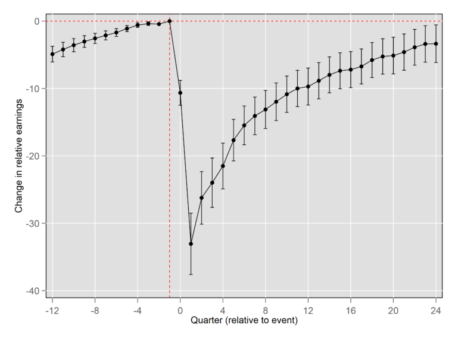

NOTE: figure/graphic rendered as an image from the PDF; its content is not machine-readable text. Caption (if any) follows as the next block.

12

Figure 3: The impact of mass layoffs on relative earnings

*Notes: Estimates of time-to-event dummies from a regression of relative earnings that also controls for individual fixed effects and quarter dummies. Coefficient estimates of the time-to-event dummies are relative to quarter directly preceding the mass layoff. Vertical bars indicate the estimated 95% confidence interval based on standard errors that are clustered at the level of 83 occupations. Source: IEB.*

Figure 1 in the introduction was created in the same way as Figure 3, but separately for workers initially employed in occupations from the first and the fourth quarter of the routine-intensity distribution. This figure already suggested that the adjustment to job loss varies with the degree of routineintensity. While the profile of earnings growth was quite similar in the period before the mass layoff, the initial earnings drop is considerably larger and more persistent for workers from high-routine occupations. Panels B and C of Table A5 show that this stems from a larger initial drop and slower adjustment in both employment and wages.

However, one might object that workers in occupations at the extremes of the distribution of routineintensity are not comparable in many ways. In particular, workers might self-select into occupations with different routine-intensities according to (unobserved) characteristics that also determine their labour market outcomes after the layoff. Our baseline results therefore stem from Equation (2), where we interact the time-to-event indicators with a continuous measure of routine-intensity and control for occupational group-specific developments.

4.2 Baseline specification Figure A5 in the appendix shows the estimated coefficients of the interaction terms of the time-toevent indicators with our continuous measure of routine-intensity. The interpretation of these estimates is by how many percentage points the earnings loss in the *k*th quarter (relative to the quarter before the layoff) is magnified due to a one percentage point increase in routine-intensity. Alternatively, these coefficients indicate the proportional difference in the change in earnings in

Page 15

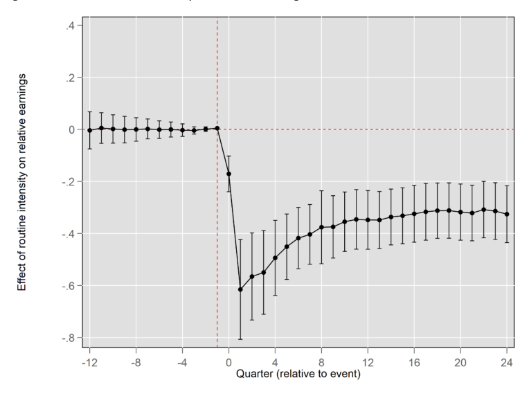

NOTE: figure/graphic rendered as an image from the PDF; its content is not machine-readable text. Caption (if any) follows as the next block.

13

quarter *k* between two workers whose routine-intensity differs by one percentage point. None of the coefficients differs significantly from zero prior to the event. However, there is a clear linear downwards trend. This indicates that workers in more routine-intensive jobs experienced slightly smaller real wage growth compared to workers in less routine-intensive jobs. Extrapolating this trend to the right, as shown by the dashed line, suggests that workers in more routine-intensive jobs would experience a decline in earnings even if they had not experienced a mass layoff. We take this development into consideration in the estimation of the effects of routine-intensity on the outcomes by linearly extrapolating the pre-event trend and then calculating the effect of routine-intensity as the difference between the estimated coefficient of the interaction term and the extrapolated pre-event trend.<sup>8</sup>

Figure 4: Effect of routine-intensity on relative earnings

*Notes: Units of observation are individual-level relative earnings within a quarter. Relative earnings are the ratio of the earnings during a specific quarter and the average earnings level during the period before the mass layoff. Quarters are measured relative to the event of the mass layoff and indicate periods before (negative values) and after the layoff (positive values). The graph shows the estimated coefficients of the interactions between the treatment variable and the time-to-event dummies. The estimates have been purged of a linear trend in the coefficient estimates of the period before the mass layoff. The unadjusted estimates are available in* Figure A5*. Vertical bars indicate the estimated 95% confidence interval. Standard errors are clustered at the level of 83 occupations. Sources: IEB, BIBB-IAB employee survey.*

Figure 4 shows the so-adjusted estimates. The pattern looks somewhat similar to the results for the overall income losses after experiencing a mass layoff. After the layoff, all interaction terms have large negative estimated coefficients, which does not change even after correcting for differences in preevent trends. The strong earnings decline in the quarter after the layoff is magnified by 0.6 percentage

8 This correction, however, is relatively small. The estimated interaction terms are predicted to decrease by approximately 0.0037 units per quarter.

Page 16

14

points for workers who prior to the layoff that used to be employed in an occupation for which the routine-intensity is larger by one percentage point. This amounts to around two percent of the overall earnings decline. The routine-penalty declines over time but remains substantial throughout the observation period and levels off at around 0.3 percentage points.

Table 4: Effects of routine-intensity on labour market outcomes

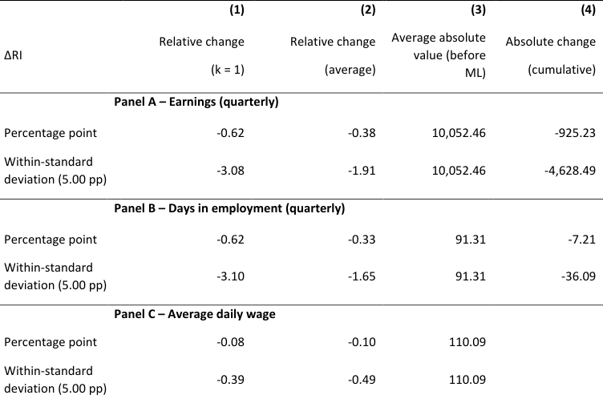

NOTE: complex table shown as an image of the PDF; the text below is a rough machine extraction and may be mis-aligned.

**extracted text (unreliable layout)**

*Notes: The table shows different marginal effects of routine-intensity on each of the relative outcome variables evaluated for changes in routine-intensity by one percentage point or by one within-standard deviation. The within-standard deviation refers to the standard deviation of the residuals that are derived from a regression of the routine-intensity variable on fixed effects for 32 occupational groups (‘Berufsabschnitte’). Column (1) contains the marginal effect in the first quarter after the mass layoff, while Column (2) shows the average marginal effect over the whole period after the mass layoff. Column (3) shows the average value of earnings, employment duration and average wages during the period before the mass layoff. Column (4) shows the absolute cumulative marginal effect over the whole period following the mass layoff and is computed for a worker with an average value of earnings during the pre-event period. Sources: IEB, BIBB-IAB employee survey.*

Panel A of Table 4 quantifies the difference in the change in earnings due to a difference in the degree of initial routine-intensity in three different ways. Column (1) shows that a difference in routineintensity by one percentage point on average further reduces the earnings in the first quarter after the mass layoff by approximately 0.6 percentage points relative to average earnings before the layoff, ceteris paribus. We also show the effects that result from a change in routine-intensity by one withinoccupational group standard deviation after purging the routine-intensity variable from the variation that exists between 32 broader occupational groups. For the first quarter, the additional earnings decline due to a difference in routine-intensity by one such standard deviation, which amounts to approximately 5 percentage points, is a further reduction in earnings by 3.1 percentage points, ceteris paribus.

As illustrated by Figure 4, the negative impact of routine-intensity on subsequent earnings subsides with time. Reflecting this pattern, the average proportional effect amounts to 0.4 percentage points for an increase in routine-intensity by one percentage point and to 1.9 percentage points in the case of an increase by one within standard deviation. In order to obtain an intuition for the absolute

Page 17

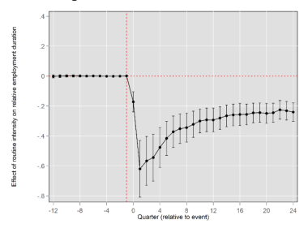

NOTE: figure/graphic rendered as an image from the PDF; its content is not machine-readable text. Caption (if any) follows as the next block.

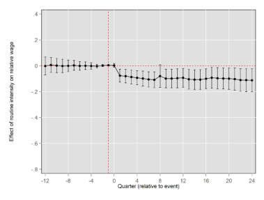

NOTE: figure/graphic rendered as an image from the PDF; its content is not machine-readable text. Caption (if any) follows as the next block.

15

magnitude of the effects, we last calculate the expected changes in earnings for a worker with the mean level of earnings (displayed in column 3) for each of the quarters of the post-layoff period. Column (4) contains the sum of these quarter-specific changes over the six years after the event. A difference in routine-intensity by one percentage point leads to a cumulated earnings loss of approximately 925 Euros, while the additional reduction in earnings for a change by one standard deviation amounts to 4,600 Euros.

4.3 Decomposition The previous sub-section showed that otherwise identical workers, on average, suffer a larger drop in earnings if they were initially employed in more routine-intensive occupations. This might be explained by workers in more routine-intensive occupations being more likely to switch to lower paid occupations as suggested by Cortes (2016). However, while this literature usually assumes instantaneous adjustment, another explanation is that many displaced workers find a new job only after a period of unemployment. This period might be longer for workers laid-off in more routineintensive occupations because employment in these occupations has been on the decline as shown in Figure 2. Since quarterly earnings are the product of days in employment per quarter and average daily earnings, we now discriminate between these channels.

In order to do so, we estimate Equation (2) separately for the number of days in employment per quarter and the average daily wage per quarter, both normalized by the worker’s averages before the layoff.<sup>9</sup> Figure 5 shows the estimated coefficients of the interaction term between time-to-event dummies and the routine-intensity for both outcome variables which have been linearly adjusted for the pre-event trend. In the case of days in employment, the pattern of the estimates largely resembles those for the relative earnings, whereas the effect on relative wages appear relatively small and do not vary much over time. Specifically, we find an increase in routine-intensity by one percentage point further reduces days in employment per quarter by 0.6 percentage points relative to the average number of days during the quarters preceding the layoff. The corresponding effect for the relative wage is a reduction by an additional 0.08 percentage points.

Figure 5: Effect of routine-intensity on the relative employment duration and relative average

wage

*Notes: See Figure 4. Units of observation are an individual worker’s days in employment per quarter and the average daily wage, respectively. Unadjusted estimates are available in Figure A6 and Figure A7. Sources: IEB, BIBB-IAB employee survey.*

9 The coefficients from both models sum up approximately to the coefficients of the model of log earnings. The sum is not exactly equal to the baseline coefficients since we add 1 to the outcomes to prevent quarters with zero earnings or employment days to be omitted from the analysis.

Page 18

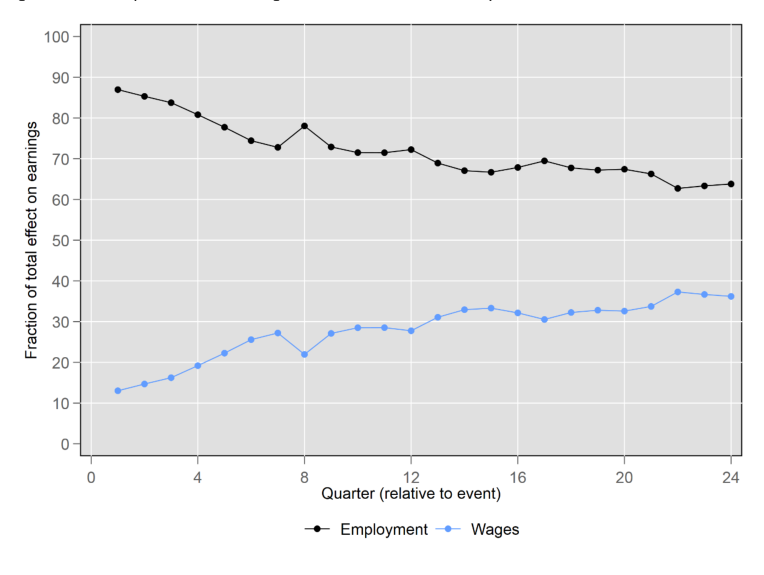

NOTE: figure/graphic rendered as an image from the PDF; its content is not machine-readable text. Caption (if any) follows as the next block.

16

To assess the relative importance of these two channels, we compute the total differential in relative earnings that results from an increase in routine-intensity by one percentage point which works through a change in employment and wages. To evaluate the magnitude of the effect we compute it at the mean value of employment duration and average wages during the period before the mass layoff:

𝜕(𝐸𝑖𝑜𝑡𝐸̅𝑖𝑜 ⁄ ) 𝜕𝑅𝐼 𝐸̅𝑖𝑜≈[<sup>𝜕(𝐿</sup><sup>𝑖𝑜𝑡</sup><sup>𝐿̅</sup><sup>𝑖𝑜</sup> ⁄ ) 𝜕𝑅𝐼 𝐿̅𝑖𝑜] 𝑊̅𝑖𝑜+ [<sup>𝜕(𝑊</sup><sup>𝑖𝑜𝑡</sup><sup>𝑊̅</sup><sup>𝑖𝑜</sup> ⁄ ) 𝜕𝑅𝐼 𝑊̅𝑖𝑜] 𝐿̅𝑖𝑜 (3)

**equation / math rendering (image)**

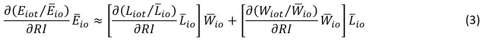

NOTE: contains mathematical notation; text above is the PDF text layer and symbols may be mis-extracted. Image shows the original.

The first part on the right hand side of Equation (3) represents the effect of routine-intensity that can be ascribed to changes in employment duration, while the second part captures the corresponding effect due to changes in wages. In the first quarter, almost 90% of the reduction in earnings, that are brought about by a higher degree of routine-intensity, is due to non-employment, while only 10% are the result of earnings lower wages. Over time, the fraction of the earnings effect that can be ascribed to wages increases to about one third as shown in Figure 6. Overall, these results provide evidence that the larger costs of job loss associated with a higher degree of routine-intensity are due to a large extent to non-employment. This contradicts the finding of Bachmann et al. (2019), who find that workers in more routine-intensive jobs are more likely to become unemployed but do not find an effect on the duration of unemployment. This difference might stem from the fact that we focus on a specific group on routine workers – those who experienced a mass layoff – to account for selection issues.

Figure 6: Decomposition of earnings effect of routine-intensity

*Notes: Computed for mean values during the period before the mass layoff. Sources: IEB, BIBB-IAB employee survey.*

Page 19

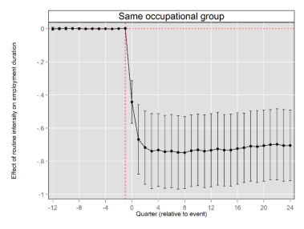

NOTE: figure/graphic rendered as an image from the PDF; its content is not machine-readable text. Caption (if any) follows as the next block.

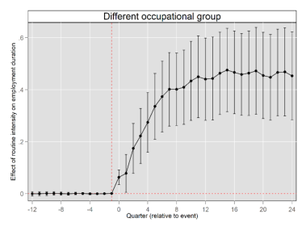

NOTE: figure/graphic rendered as an image from the PDF; its content is not machine-readable text. Caption (if any) follows as the next block.

17

4.4 Subsequent transitions into employment We have shown that mass layoffs lead to large and persistent reductions in earnings for all workers, but that for workers who used to be employed in routine-intensive occupations, the costs of job loss are more severe and more persistent. In this sub-section we aim to analyse in more detail how subsequent employment biographies are shaped by the routine-intensity of the previous occupation. After having been employed in an occupation for a certain time, workers possess a specific human capital either acquired by on-the-job learning or because they needed to have certain skills in order to get their specific job in the first place. Previous evidence has shown that displaced workers are particularly at risk of losing this specific human capital because they are often forced to switch to different occupations that either use different skills compared to the previous occupation or the same skills but by a lower intensity (Robinson, 2018). For more routine-intensive occupations, the additional problem is that the demand for them decreased constantly during the past decades, as shown in Figure 2, which further increases the likelihood to involuntarily switch to a different occupation. While job protection legislation might have shielded these workers to a certain degree on the job, they are exposed to this development after displacement and when searching for a new job.

Figure 7: Effects on the duration of employment by same vs. different occupational group

Panel A: Same occupational group Panel B: Different occupational group

*Notes: See Figure 4. For the pre-event period, the dependent variable is given by the number of days in employment per quarter; during the post-event period the dependent variable takes on non-zero values only in those quarters during which a worker is employed in the same occupation as (Panel A) or a different occupation than (Panel B) during the quarter directly preceding the mass layoff. Sources: IEB, BIBB-IAB employee survey.*

To shed further light on the adjustment processes of laid-off workers in times of technological change, we assess the impact of routine-intensity on the ability of taking up employment in higher-quality jobs – as measured by average daily wages – as well as on occupational and regional mobility. To this end, we estimate several variations on Equation (2). For the first variation, we use we differentiate quarterly employment during the post-event period according to whether a worker is employed in the same or in a different occupational group as compared to the quarter before the layoff.<sup>10</sup> For example, when we are interested in the effect of routine-intensity on employment chances in the worker’s initial occupational group, we set the employment duration to zero for all post-layoff observations where a worker is either unemployed or employed in a different occupational group. This way, the coefficients of the interaction terms that belong to post-layoff quarters add up to the overall effect on the number

Page 20

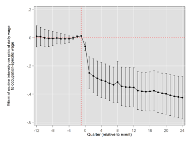

NOTE: figure/graphic rendered as an image from the PDF; its content is not machine-readable text. Caption (if any) follows as the next block.

18

of days in employment per quarter. In the same way, we differentiate employment in the same county as opposed to a different county.<sup>11</sup>

Panel A of Figure 7 shows that the workers who previously held a more routine-intensive occupation are less likely to return to this or a similar occupation after the layoff. This corroborates the hypothesis that in times of declining demand for routine occupations, the job-specific skills of workers in routineintensive jobs lose value immediately in the case of a layoff. As Panel B shows, the more routineintensive the previous job was, the more likely it is that subsequent employment will be in a different occupation.

Having established that more routine-intensive workers are more likely to switch to a different occupation, it is also interesting to consider the quality of the new jobs. This quality has two dimensions: first, workers could switch into an occupation with a higher or lower average wage compared to their previous occupation. Second, they could enter the new occupation at a specific part of the wage distribution within the new occupation. The former is difficult to analyse: since routineintensive occupations tend to be at the lower end of the wage distribution in Germany, workers leaving those occupations are more likely to move to an on average better paid occupations by definition. We therefore concentrate on the latter and measure the quality of the job as the individual’s daily wage relative to the average wage of incumbent workers in this occupation.

Figure 8: Effects on own wage relative to occupation-specific mean wage

*Notes: See Figure 4. The dependent variable is defined as worker-specific average daily wages relative to the daily wages that are paid on average in the occupation that the worker is employed in at time t. Occupation-specific average wages are computed from a comparison sample of workers as described in Section 2.1. Sources: IEB, BIBB-IAB employee survey.*

11 Similar results are obtained when using the 32 values of the *Berufsabschnitte*. Likewise, comparable patterns emerge when labour-market regions are used instead of counties. Results are available upon request.

Page 21

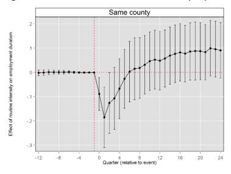

NOTE: figure/graphic rendered as an image from the PDF; its content is not machine-readable text. Caption (if any) follows as the next block.

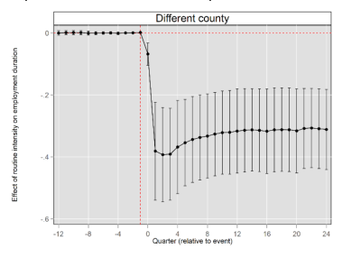

NOTE: figure/graphic rendered as an image from the PDF; its content is not machine-readable text. Caption (if any) follows as the next block.

19

Finally, we look at regional mobility as a possible adjustment mechanism to a mass layoff. Figure 9 shows that a higher degree of routine-intensity has a negative effect on subsequent employment in a different county. While employment in routine-intensive occupations is associated with subsequently finding employment in a different occupation, it is also related to lower regional mobility. Both findings might be related: Due to the mass layoff, there might be an oversupply of job seekers searching for a new job in a certain occupation. Regional mobility might increase an individual’s probability of finding an adequate new job and at the same time reduce the competition among the remaining job seekers.

Figure 9: Effects on the duration of employment by same vs. different county

Panel A: Same county Panel B: Different county

*Notes: See Figure 4. For the pre-event period, the dependent variable is given by the number of days in employment per quarter; during the post-event period the dependent variable takes on non-zero values only in quarter during which a worker is employed in the same county as (Panel A) or a different county than (Panel B) during the quarter directly preceding the mass layoff. Sources: IEB, BIBB-IAB employee survey.*

4.5 Effect heterogeneity and robustness checks In this paper, we deviate from the traditional way to construct a measure for the routine-intensity of an occupation from data of the BIBB-IAB-*Erwerbstätigenbefragung* used in previous studies (e.g. Spitz‐ Oener, 2006; Antonczyk et al., 2009; Black and Spitz-Oener, 2010). We argue that the design of the surveys prohibits a time-consistent measurement of routine-intensity. To ensure comparability with other studies, and to demonstrate that our results do not hinge on this decision, we also construct a routine-intensity measure that is based on the share of tasks in the survey that can be classified as routine. We proceed to compare the positions of the 83 occupations in the distribution of the routineintensity variable that is used in this paper and the task-based measure.

Figure A1 shows that there is a considerable positive correlation between the measure of routineintensity used in this paper and the task-based measure for each of the three decades under study. This is especially the case at the ends of the distribution suggesting that both approaches identify similar of occupations as being the most and least routine-intensive. The correlation coefficient between our measure and the traditional one is 0.6.

Next, we replicate the empirical analysis of equation (2) using the traditional task-based routineintensity variable. The results of this robustness check are reported in Table 5. Again, we measure the additional costs of displacement due to a difference in routine-intensity in three ways: Directly after the event, on average over the entire post-event period and the cumulative costs. Since the variation of this routine-measure differs from our routine-intensity, we again compute the within-occupational group standard deviation to evaluate those effects. The effects of a one within-standard deviation difference in routine-intensity are comparable to our baseline results in Table 4. We therefore conclude that our results do not stem from the choice of how to measure routine-intensity but rather

Page 22

20

base on the underlying mechanism that workers in more routine-intensive occupations find it more difficult to adjust to a break in their employment career.<sup>12</sup>

Table 5: Effects of routine-intensity on labour market outcomes using a task-based measure of

routine-intensity

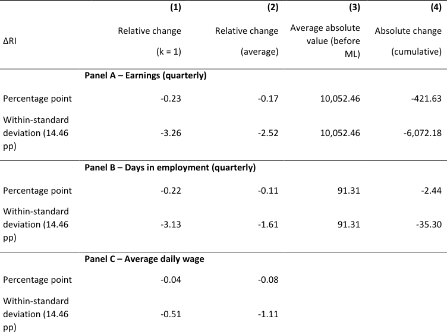

NOTE: complex table shown as an image of the PDF; the text below is a rough machine extraction and may be mis-aligned.

**extracted text (unreliable layout)**

*Notes: See Table 4. A task-based measure of routine-intensity is used. Sources: IEB, BIBB-IAB employee survey.*

12 The corresponding event-study plots can be found in Figure A2, Figure A3 and Figure A4.

Page 23

21

Table 6: Effects of routine-intensity on earnings by population groups

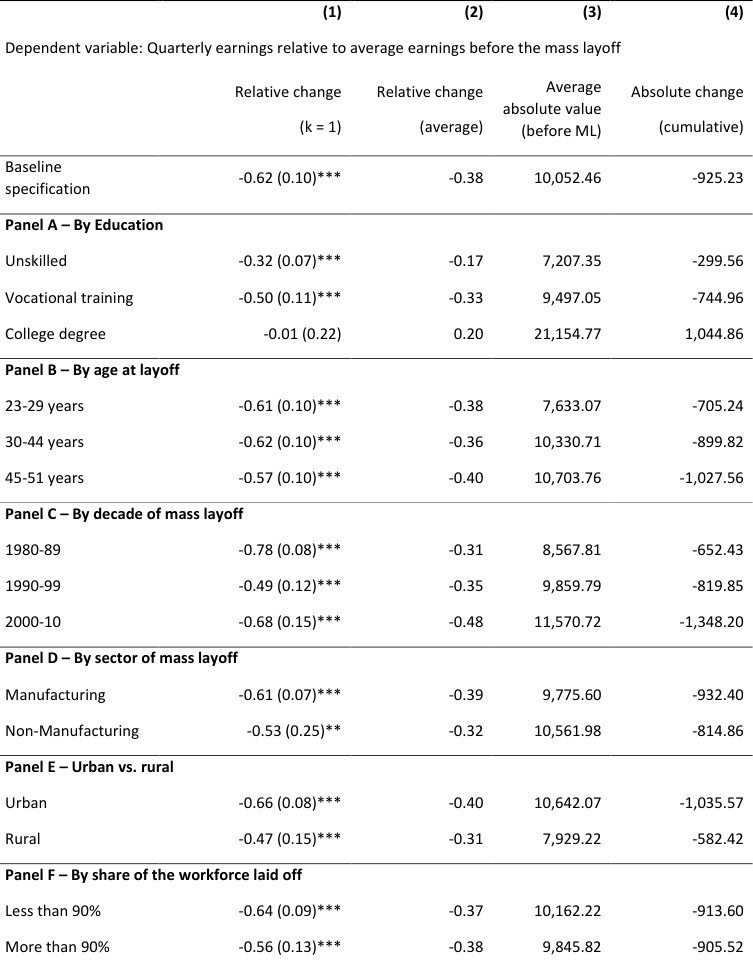

NOTE: complex table shown as an image of the PDF; the text below is a rough machine extraction and may be mis-aligned.

**extracted text (unreliable layout)**

*Notes: See Table 4. Marginal effects are computed for different sub-groups. Column (1) contains standard errors in parentheses and significance levels: *** (0.01), ** (0.05), * (0.10). Sources: IEB, BIBB-IAB employee survey.*

Page 24

22

Finally, we run a number of additional robustness checks and report the results in Table A4. While the baseline specification employs worker fixed effects in order to control for the effects of individual- and establishment-level characteristics from the quarter preceding the mass layoff (as well as unobservable time-invariant influences), Panel A shows the results from a specification that uses these variables instead of the fixed effects. The estimated effects are qualitatively similar, albeit slightly smaller as suggested by the smaller absolute change shown in column 4. The results in Panel B derive from the same empirical model as specified in Equation (2), but are based on different forms of the routine-intensity measure. First, we assess the sensitivity of the results by extending the definition of routine-intensity to the share of workers in an occupation reporting both items to be the case ‘almost always’ or ‘often’. As expected, including workers for whom routines are not as common reduces the magnitude of the effects, although the former remain negative. Finally, we use routine-intensity measures that rely on a single wave of the ‘employee survey’. The estimated effects are negative in each case. However, the magnitude of the absolute change in column 4 is largest if the data from the 1985 survey is used and smallest for the 1991 survey suggesting that not taking into account changes in occupational job contents results in an over- or underestimation of the effects.

5 Conclusion There is a broad consensus that technological change is routine-biased and has led to the secular decline of routine-intensive jobs. This paper assesses how this secular trend affects individual workers. We argue that in a country like Germany, labour market institutions shield workers to a certain degree from the immediate effects of technological change. If a firm wants to replace employees in routineintensive occupations by machines or by different workers specialized in less routine-intensive tasks, job protection laws or works councils might influence the selection process. We hence concentrate on a group of individuals that are particularly vulnerable: workers who lost their job during a mass layoff event. Those workers are forced by exogenous reasons to adjust to both, the layoff itself and the consequences of technological change.

Our findings on the overall costs of experiencing a mass layoff are in line with the extant literature. However, even comparing only similar workers in the same occupation group, we find that workers who worked in a routine-intensive occupation prior to the layoff have more difficulties to recover from the layoff. With each additional standard deviation of routine-intensity, the total earnings losses over the subsequent six years increase on average by 4,628 Euros. Initially, almost 90 percent of this additional loss stems from a reduced time in employment, while the rest stems from employment at

Page 25

23

a lower wage. This suggests that there is a modest additional disadvantage for routine workers on top of the wage reduction experienced by all workers who lost their previous job due to a mass layoff. However, a more important mechanism is that the time it takes to find an adequate new job appears to increase with the routine-intensity of the previous job. This highlights the importance of unemployment in the adjustment to technological change. Transitions to new employment appear not to be as smooth as often assumed by the theoretical literature.

Our analysis provides additional insights on the quality of job switches of routine workers. Workers who previously held a more routine-intensive occupation are less likely to find a new job in the same or similar occupation and are more likely to end up at the bottom of the wage distribution of their new occupation. This is in line with the literature on the mobility of routine workers into non-routine occupations and on the loss of specific human capital.

These results highlight an additional channel of how routine-biased technological change affects the labour market on the intensive margin. Once confronted with an exogenous shock to their careers, workers in routine-intensive occupations face persistently worse labour market outcomes for the rest or their working life. This fosters income inequality since routine-intensive jobs are typically located at the lower part of the wage distribution – at least in Germany. Labour market policies targeted at routine workers should thus aim to improve the employability of those workers either at their original workplace even before a possible layoff or in different firms.

Acknowledgements We would like to thank Melanie Arntz, Matias Cortes, Joachim Möller, Mark Partridge, Anna Salomons, Alexandra Spitz-Oener, and Ulrich Zierahn for helpful comments and suggestions. We also appreciate the feedback received at the following meetings: the American Economic Association (Atlanta), the European Association of Labour Economists (Lyon), the German Economic Association (Freiburg), the IAB workshop on Technological Progress and the Labour Market (Nuremberg), the 2<sup>nd</sup> IZA/OECD workshop: Labor Productivity and the Digital Economy (Paris), the T.A.S.K.S. conference (Bonn) and the ZEW seminar. Finally, we thank Birgit Carl for formatting this paper. All remaining errors are our own.

Page 26

24

References **Ahlfeldt, Gabriel M.; Duncan Roth and Tobias Seidel.** 2018. "The Regional Effects of Germany’s National Minimum Wage." *Economics Letters*, 172, 127-30.

**Antonczyk, Dirk; Bernd Fitzenberger and Ute Leuschner.** 2009. "Can a Task-Based Approach Explain the Recent Changes in the German Wage Structure?" *Jahrbücher für Nationalökonomie und Statistik*, 229(2-3), 214-38.

**Autor, David H.** 2013. "The “Task Approach” to Labor Markets: An Overview." *Journal for Labour Market Research*, 46(3), 185-99.

**Autor, David H. and David Dorn.** 2013. "The Growth of Low-Skill Service Jobs and the Polarization of the Us Labor Market." *American Economic Review*, 103(5), 1553-97.

**Autor, David H.; David Dorn and Gordon H. Hanson.** 2015. "Untangling Trade and Technology: Evidence from Local Labour Markets." *The Economic Journal*, 125(584), 621-46.

**Autor, David H.; Frank Levy and Richard J. Murnane.** 2003. "The Skill Content of Recent Technological Change: An Empirical Exploration*." *The Quarterly Journal of Economics*, 118(4), 1279-333.

**Autor, David H. and Anna Salomons.** 2017. "Does Productivity Growth Threaten Employment?," *4th Annual ECB Forum on Central Banking.* Sintra, Portugal:

**Bachmann, Ronald; Merve Cim and Colin Green.** 2019. "Long-Run Patterns of Labour Market Polarization: Evidence from German Micro Data." *British Journal of Industrial Relations*, 57(2), 350-76.

**Biagi, Federico; Paolo Naticchioni; Giuseppe Ragusa and Claudia Vittori.** 2018. "Routinization and the Labour Market: Evidence from European Countries," L. Pupillo, E. Noam and L. Waverman, *Digitized Labor: The Impact of the Internet on Employment.* Palgrave Macmillan,

**Black, Sandra E. and Alexandra Spitz-Oener.** 2010. "Explaining Women's Success: Technological Change and the Skill Content of Women's Work." *The Review of Economics and Statistics*, 92(1), 187- 94.

**Cortes, Guido Matias.** 2016. "Where Have the Middle-Wage Workers Gone? A Study of Polarization Using Panel Data." *Journal of Labor Economics*, 34(1), 63-105.

**Cortes, Guido Matias and Giovanni Gallipoli.** 2018. "The Costs of Occupational Mobility: An Aggregate Analysis." *Journal of the European Economic Association*, 16(2), 275-315.

**Cortes, Guido Matias; Nir Jaimovich and Henry E. Siu.** 2017. "Disappearing Routine Jobs: Who, How, and Why?" *Journal of Monetary Economics*, 91, 69-87.

**Davis, Steven J. and Till von Wachter.** 2011. "Recessions and the Costs of Job Loss," *Brookings Papers on Economic Activity.* Economic Studies Program, The Brookings Institution, 1-72.

**Davis, Steven J.; Till Von Wachter; Robert E. Hall and Richard Rogerson.** 2011. "Recessions and the Costs of Job Loss [with Comments and Discussion]." *Brookings Papers on Economic Activity*, 1-72.

**Edin, Per-Anders; Tiernan Evans; Georg Graetz; Sofia Hernnäs and Guy Michaels.** 2019. "Individual Consequences of Occupational Decline," *CEP Discussion Papers.* London: Centre for Economic Performance, London School of Economics and Political Science,

**Fonseca, Tiago; Francisco Lima and Sonia C. Pereira.** 2018. "Job Polarization, Technological Change and Routinization: Evidence for Portugal." *Labour Economics*, 51, 317-39.

**Gathmann, Christina and Uta Schönberg.** 2010. "How General Is Human Capital? A Task‐Based Approach." *Journal of Labor Economics*, 28(1), 1-49.

Page 27

25

**Goos, Maarten; Alan Manning and Anna Salomons.** 2014. "Explaining Job Polarization: Routine-Biased Technological Change and Offshoring." *American Economic Review*, 104(8), 2509-26.

**Hethey-Maier, Tanja and Johannes F. Schmieder.** 2010. "Does the Use of Worker Flows Improve the Analysis of Establishment Turnover: Evidence from German Administrative Data.," *FDZ- Methodenreport.* Nürnberg, Germany: Institute für Arbeitsmarkt- und Berufsforschung,

**Hummels, David; Jakob R. Munch and Chong Xiang.** 2018. "Offshoring and Labor Markets." *Journal of Economic Literature*, 56(3), 981-1028.

**Jacobson, Louis S.; Robert J. LaLonde and Daniel G. Sullivan.** 1993. "Earnings Losses of Displaced Workers." *The American Economic Review*, 83(4), 685-709.

**Keynes, John Maynard.** 2010. "Economic Possibilities for Our Grandchildren," *Essays in Persuasion.* London: Palgrave Macmillan UK, 321-32.

**Lommerud, Kjell Erik and Odd Rune Straume.** 2011. "Employment Protection Versus Flexicurity: On Technology Adoption in Unionised Firms*." *The Scandinavian Journal of Economics*, 114(1), 177-99.

**Monras, Joan.** 2019. "Minimum Wages and Spatial Equilibrium: Theory and Evidence." *Journal of Labor Economics*, 37(3), 853-904.

**Oldenski, Lindsay.** 2014. "Offshoring and the Polarization of the U.S. Labor Market." *ILR Review*, 67(3_suppl), 734-61.

**Robinson, Chris.** 2018. "Occupational Mobility, Occupation Distance, and Specific Human Capital." *Journal of Human Resources*, 53(2), 513-51.

**Schmidheiny, Kurt and Sebastian Siegloch.** 2019. "On Event Study Designs and Distributed-Lag Models: Equivalence, Generalization and Practical Implications," *IZA Discussion Paper.* Bonn: IZA Institute of Labor Economics,

**Spitz‐Oener, Alexandra.** 2006. "Technical Change, Job Tasks, and Rising Educational Demands: Looking Outside the Wage Structure." *Journal of Labor Economics*, 24(2), 235-70.

Page 28

26

### Supplementary Online Appendix

A1 Identification of mass layoffs We use the IAB Establishment History Panel (BHP, version 7516 v1) to identify plants that experienced a mass layoff. This dataset includes annual information on the number of workers subject to social security on 30 June of a given year for all establishments in Germany.<sup>13</sup>

The panel structure of the BHP allows us to identify those establishments that initially have a sufficiently large and stable workforce which then contracts sharply from one year to the next and does not recover to its initial level in the following years. Specifically, for an establishment to be defined as having experienced a mass layoff, we impose the conditions that there must have been at least 50 workers employed on 30 June of year t and the size of the workforce must not have been below 80 percent or above 120 percent of that level in the two preceding years. Between the years t and t+1 the establishment’s workforce has to fall by between 30 and 100 percent and must not recover by more than 50 percent of the initial drop within the next two years.<sup>14</sup> Since the data in the BHP is at the establishment level, it is possible that large changes in the size of the workforce represent restructuring within multi-establishment firms rather than genuine mass layoffs. For this reason, we adopt the approach of Hethey-Maier and Schmieder (2010) and remove those establishments from the sample where the drop in employment is the result of restructuring rather than a genuine mass layoff.

Our dataset contains 9,230 establishments that experienced mass layoff between 1980 and 2010 and a total of 312,634 affected workers. Table A2 contains information on different characteristics of these establishments that refer to the quarter before the mass layoff. The number of establishments and workers is larger during the last two decades reflecting an increase in the workforce following the German re-unification. Initially, mass layoffs occur predominantly in manufacturing with 66% of establishments in the decade 1980-89 and 73% of workers being accounted for by that sector.<sup>15</sup> Though manufacturing remains the largest single sector in terms of mass layoffs, these shares have fallen to 43% and 56%, respectively, in the last decade. At the same time, mass layoffs have become more common in the service sectors with increases in *K – Real estate, renting and business activities*, *I – Transport, storage and communication* as well as *G – Wholesale and retail trade*. Taken together, these sectors account for 49% of the affected establishments and 37% of workers during the decade 2000-2010. More than half of the establishments in the sample employ between 50 and 99 workers, while more than 80% have workforces below 199 employees. The differences between the size groups are considerably smaller in terms of employment shares. During the second and third decade, less than one fifth of establishments are located in East Germany.

A2 Calculation of Effect of Routine-intensity This section describes how we compute the effects of routine-intensity on the different outcome variables. In a first step, we remove any long-run outcome trends that may differ between occupations that are more or less routine-intensive. This is done by linearly extrapolating the estimated interaction terms between the routine-intensity variable and the time-to-event dummies from the time period

13 Establishments must have at least one worker subject to social security contributions or, from 1999 onwards, at least one marginally employed workers. See Spengler (2008) for further details on the BHP. 14 As discussed in section 4.5, the results of the empirical analysis are robust to restricting the sample to those establishments in which the mass layoff is very close to a complete closure. 15 Sector definitions follow the *German Classification of Economic Activities (edition 1993)*. We do not consider mass layoffs that occurred in sector *O – Other community, social and personal service activities*.

Page 29

27

before the mass layoff (see Ahlfeldt et al., 2018 and Monras, 2019 for further examples of this procedure). Specifically, we regress the coefficient estimates of *γk* on a constant and a linear trend:

𝛾̂𝑘|𝑘≤−1 = 𝜋0 + 𝜋1𝑘+ 𝑤𝑘 (4)

**equation / math rendering (image)**

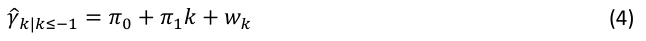

NOTE: contains mathematical notation; text above is the PDF text layer and symbols may be mis-extracted. Image shows the original.

The estimated coefficients of the above equation form the basis for computing the counterfactual for the post-event period, which we subtract from the event study estimates:

𝜏̂𝑘|𝑘>−1 = 𝛾̂𝑘−(𝜋̂0 + 𝜋̂1𝑘) (5)

**equation / math rendering (image)**

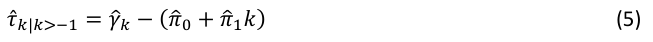

NOTE: contains mathematical notation; text above is the PDF text layer and symbols may be mis-extracted. Image shows the original.

Based on this adjustment we compute three types of effects. First, we report the change in the relative outcome during the first quarter after the mass layoff. Second, we compute the average value of this effect over all quarters following the mass layoff, which takes into account the fact that the magnitude of the effects change over time. Next, we use the average value of the outcome variables before the mass layoff to compute an estimate of the absolute change in the outcome for each quarter following the mass layoff. Our third measure is then given by the sum of these quarter-specific effects.

We report each of those three measures for a difference in routine-intensity *∆RI* by one percentage point. A more natural difference might be the standard deviation of *RI*. Yet, our identification strategy hinges on small differences in *RI* for otherwise comparable workers. We therefore also report each measure for *∆RI* equal to the within occupation group standard deviation of *RI*. To this end, we first regress *RI* on dummy variables for 32 aggregate occupation groups (*Berufsabschnitte*). Then we use the law of total variance and compute the within occupation group standard deviation as the standard deviation of the residuals from this regression.

A3 Alternative Routine Measure Section 2.2 describes how occupational routine-intensity is defined in this paper and how a corresponding measure is constructed from the *employee survey*. Since other papers have made use of a task-based measure that is derived from the same dataset, we showed in section 4.5 that the results are robust to using this measure of routine-intensity. In the following we detail the construction of the task-based measure.

After employing the same sample restrictions as outlined in section 2.2, we compute the share of routine tasks for each worker in the sample. Routine tasks consist of routine cognitive and routine manual tasks. Since the list of tasks differs between the surveys, we document how we classify routine tasks in Table A1 (in doing so, we follow Table 1 in Spitz‐Oener, 2006 and Table 4 in Antonczyk et al., 2009 as closely as possible). For routine-intensity at the occupational level we compute an hoursadjusted share of routine tasks.

Page 30

28

#### A4 Appendix Tables and Figures

Table A1: Classification of routine tasks

| Wave | Routinecognitivetasks | Routinemanualtasks |
| --- | --- | --- |
| 1985 | Schreibarbeiten/Schriftverkehr , | Maschinen Automaten Anlageneinrichten , , , |
|  | Formulararbeiten | einstellen umrüsten programmieren , , |
|  | Kalkulieren/berechnen buchen , | Maschinen Automaten Anlagenbedienen , , , |
|  |  | steuern beschicken , |
|  |  | Anbauen züchten hegen;gewinnen/abbauen , , , |
|  |  | fördern |
|  |  | Stoffeerzeugen ausformen; , |
|  |  | verarbeiten/bearbeiten kochen , |
|  |  | Bauen/ausbauen installieren montieren , , |
| 1991 | Schreibarbeiten Schriftverkehr , , | Maschinen/Anlageneinrichten einstellenusw , . |
|  | Formulararbeiten | Maschinen/Anlagenbedienen steuernusw , . |
|  | Kalkulieren berechnen buchen , , | Pflanzenanbauen/Tierezüchten |
|  |  | Rohstoffegewinnen abbauen fördern , , |
|  |  | Stoffeerzeugen verarbeiten Speisenbereiten , , |
|  |  | Gebäude/Anlagen/Geräte bauen montieren , |
|  |  | usw . |
|  |  | Packen verladen versenden zustellen , , , |
|  |  | Sortieren ablegen auszeichnenusw , , . |
| 1999 | Messen Prüfen Qualitätskontrolle , , | Überwachen SteuernvonMaschinen Anlagen , , , |
|  |  | technischenProzessen |
|  |  | Herstellen ProduzierenvonWarenundGütern , |

NOTE: table converted from PDF layout to HTML text; cell boundaries are reconstructed. See PDF if exact alignment matters.

Page 31

29

Table A2: Establishment characteristics

| PanelA –Establishmentlevel | 1980 1989 - |  | 1990 1999 - |  | 2000 2010 - |  | 1980 2010 - |  |
| --- | --- | --- | --- | --- | --- | --- | --- | --- |
|  | mean | sd | mean | sd | mean | sd | mean | sd |
| D –Manufacturing | 6580 . | (4745) . | 5889 . | (4921) . | 4321 . | (4955) . | 5514 . | (4974) . |
| E – Electricity , gas , and water supply | 030 . | (546) . | 069 . | (825) . | 040 . | (632) . | 049 . | (697) . |
| F –Construction | 243 . | (1541) . | 1989 . | (1363) . | 188 . | (1359) . | 203 . | (1409) . |
| G –Wholesaleandresale trade | 1917 . | (3937) . | 1876 . | (3904) . | 2209 . | (4149) . | 2003 . | (4003) . |
| H –Hotelsandrestaurants | 115 . | (1068) . | 181 . | (1333) . | 265 . | (1607) . | 194 . | (1379) . |
| I – Transport , storage and communication | 406 . | (1973) . | 773 . | (2672) . | 965 . | (2954) . | 748 . | (2630) . |
| J –Financialintermediation | 149 . | (1214) . | 176 . | (1313) . | 238 . | (1523) . | 191 . | (1368) . |
| K – Real estate , renting and businessactivities | 559 . | (2298) . | 848 . | (2785) . | 1774 . | (3820) . | 1100 . | (3129) . |
| 50 -99 employees | 5649 . | (4959) . | 5743 . | (4945) . | 6169 . | (4862) . | 5869 . | (4924) . |
| 100 -199 employees | 2643 . | (4411) . | 2658 . | (4418) . | 2514 . | (4339) . | 2603 . | (4388) . |
| 200 -499 employees | 1388 . | (3458) . | 1210 . | (3261) . | 1046 . | (3060) . | 1197 . | (3246) . |
| 500ormoreemployees | 320 . | (1761) . | 389 . | (1935) . | 271 . | (1625) . | 330 . | (1788) . |
| EastGermany | 282 . | (1655) . | 1610 . | (3676) . | 1771 . | (3818) . | 1329 . | (3395) . |
| Observations | 2342 , |  | 3646 , |  | 3242 , |  | 9230 , |  |
| PanelB –Workerlevel | 1980 1989 - |  | 1990 1999 - |  | 2000 2010 - |  | 1980 2010 - |  |
|  | mean | sd | mean | sd | mean | sd | mean | sd |
| D –Manufacturing | 7317 . | (4431) . | 6574 . | (4746) . | 5641 . | (4959) . | 6479 . | (4776) . |
| E – Electricity , gas , and water | 034 . | (586) . | 290 . | (1678) . | 089 . | (938) . | 155 . | (1235) . |
| supply |  |  |  |  |  |  |  |  |
| F –Construction | 261 . | (1594) . | 106 . | (1022) . | 120 . | (1090) . | 153 . | (1228) . |
| G –Wholesaleandretail | 1306 . | (3369) . | 1392 . | (3461) . | 1876 . | (3904) . | 1524 . | (3594) . |
| trade |  |  |  |  |  |  |  |  |
| H –Hotelsandrestaurants | 030 . | (544) . | 073 . | (854) . | 104 . | (1015) . | 071 . | (841) . |
| I – Transport , storage and | 307 . | (1725) . | 863 . | (2808) . | 678 . | (2514) . | 650 . | (2465) . |
| communication |  |  |  |  |  |  |  |  |
| J –Financialintermediation | 144 . | (1193) . | 154 . | (1231) . | 309 . | (1730) . | 201 . | (1404) . |
| K – Real estate , renting and | 601 . | (2377) . | 549 . | (2277) . | 1183 . | (3230) . | 767 . | (2661) . |
| businessactivities |  |  |  |  |  |  |  |  |
| 50 -99 employees | 2508 . | (4335) . | 2783 . | (4482) . | 3194 . | (4662) . | 2839 . | (4509) . |
| 100 -199 employees | 2487 . | (4323) . | 2663 . | (4420) . | 2588 . | (4380) . | 2590 . | (4381) . |
| 200 -499 employees | 2882 . | (4529) . | 2562 . | (4365) . | 2124 . | (4090) . | 2510 . | (4336) . |
| 500ormoreemployees | 2123 . | (4090) . | 1992 . | (3994) . | 2094 . | (4069) . | 2061 . | (4045) . |
| EastGermany | 240 . | (1531) . | 1796 . | (3839) . | 1439 . | (3510) . | 1252 . | (3309) . |
| Observations | 86310 , |  | 125942 , |  | 100382 , |  | 312634 , |  |

NOTE: table converted from PDF layout to HTML text; cell boundaries are reconstructed. See PDF if exact alignment matters.

*Notes: The table shows the share of establishments (Panel A) and workers (Panel B) in percentage points as well as the corresponding standard deviations for various establishment-level characteristics. Source: IEB.*

Page 32

30

Table A3: Occupational routine-intensity

|  |  | 1985 |  |  | 1991 |  |  | 1999 |  |
| --- | --- | --- | --- | --- | --- | --- | --- | --- | --- |
| Occupation | Rank | Routine- intensity | Obs (weighted) | Rank | Routine- intensity | Obs (weighted) | Rank | Routine- intensity | Obs (weighted) |
| Mineralpreparers | 1 | 4929 . | 140 . | 82 | 000 . | 473 . | 83 | . | . |
| Othernutrition |  |  |  |  |  |  |  |  |  |
| occupations | 2 | 4336 . | 2562 . | 4 | 4183 . | 2216 . | 8 | 3609 . | 2932 . |
| Textilemakers | 3 | 4055 . | 5068 . | 18 | 2363 . | 2019 . | 2 | 5709 . | 1790 . |
| Assistants(nofurther specification) | 4 | 3732 . | 69443 . | 9 | 3313 . | 49701 . | 9 | 3549 . | 49421 . |
| Buildingmaterialmakers | 5 | 3550 . | 1766 . | 3 | 4215 . | 1153 . | 22 | 2124 . | 1043 . |
| Spinners | 6 | 3402 . | 1505 . | 1 | 5945 . | 1699 . | 24 | 1873 . | 625 . |
| Metal producers, Rollers | 7 | 3229 . | 6783 . | 24 | 1933 . | 4190 . | 12 | 2982 . | 4009 . |
| AssemblersandMetal |  |  |  |  |  |  |  |  |  |
| workers(nofurther | 8 | 3224 . | 20763 . | 6 | 3721 . | 21693 . | 10 | 3394 . | 15097 . |
| specification) |  |  |  |  |  |  |  |  |  |
| Textileprocessers | 9 | 3067 . | 19726 . | 11 | 3120 . | 17210 . | 14 | 2764 . | 9347 . |
| Metal moulders (non- cuttingdeformation) | 10 | 3040 . | 9273 . | 5 | 3903 . | 5173 . | 3 | 4567 . | 2103 . |
| Glassmakers | 11 | 3019 . | 2653 . | 26 | 1690 . | 3183 . | 6 | 4083 . | 2377 . |
| Plasticsprocessors | 12 | 2991 . | 5848 . | 17 | 2487 . | 3917 . | 17 | 2601 . | 4124 . |
| Goods examiner, despatchers | 13 | 2969 . | 24299 . | 10 | 3261 . | 27931 . | 11 | 3153 . | 27852 . |
| Metalconnectors | 14 | 2891 . | 7711 . | 8 | 3403 . | 12182 . | 34 | 1329 . | 8360 . |
| Chemicalworkers | 15 | 2840 . | 20117 . | 20 | 2167 . | 18428 . | 20 | 2206 . | 18391 . |
| Beverage makers, Luxuryfoodmakers | 16 | 2835 . | 2963 . | 19 | 2332 . | 1835 . | 5 | 4134 . | 4415 . |
| Cleaningoccupations | 17 | 2780 . | 25792 . | 7 | 3452 . | 27369 . | 13 | 2821 . | 29352 . |
| Ceramicsworkers | 18 | 2662 . | 3152 . | 2 | 5433 . | 2910 . | 19 | 2229 . | 2743 . |
| Machinistsandrelated |  |  |  |  |  |  |  |  |  |
| occupations | 19 | 2407 . | 30690 . | 22 | 1986 . | 48172 . | 18 | 2280 . | 40866 . |
| Wood preparers, Wood |  |  |  |  |  |  |  |  |  |
| productsmakersand | 20 | 2392 . | 4690 . | 36 | 1210 . | 2720 . | 27 | 1528 . | 3507 . |
| relatedoccupations |  |  |  |  |  |  |  |  |  |
| Moulders, Mould casters | 21 | 2386 . | 3843 . | 13 | 3087 . | 3933 . | 4 | 4399 . | 3730 . |
| Leather makers, Leather |  |  |  |  |  |  |  |  |  |
| andSkinprocessing | 22 | 1912 . | 5658 . | 16 | 2605 . | 3348 . | 38 | 1204 . | 2342 . |
| operatives |  |  |  |  |  |  |  |  |  |
| Textilefinisher | 23 | 1912 . | 1391 . | 14 | 3035 . | 893 . | 1 | 6323 . | 419 . |
| Watchpersonsand relatedworkers | 24 | 1906 . | 22571 . | 30 | 1533 . | 28677 . | 40 | 1172 . | 29764 . |
| Communication |  |  |  |  |  |  |  |  |  |
| occupations | 25 | 1795 . | 9846 . | 12 | 3108 . | 9874 . | 16 | 2635 . | 9822 . |

NOTE: table converted from PDF layout to HTML text; cell boundaries are reconstructed. See PDF if exact alignment matters.

Page 33

31

|  |  | 1985 |  |  | 1991 |  |  | 1999 |  |
| --- | --- | --- | --- | --- | --- | --- | --- | --- | --- |
| Occupation | Rank | Routine- intensity | Obs (weighted) | Rank | Routine- intensity | Obs (weighted) | Rank | Routine- intensity | Obs (weighted) |
| Metal moulders (metal - cuttingdeformation) | 26 | 1625 . | 15303 . | 31 | 1507 . | 28827 . | 30 | 1468 . | 16243 . |
| Foodpreparers | 27 | 1572 . | 17947 . | 55 | 647 . | 26572 . | 48 | 898 . | 26733 . |
| Surfacetransport | 28 | 1491 . | 81743 . | 25 | 1910 . | 96102 . | 21 | 2144 . | 89520 . |
| occupations |  |  |  |  |  |  |  |  |  |
| Artists | 29 | 1478 . | 10903 . | 44 | 825 . | 12104 . | 67 | 321 . | 9371 . |
| Bakery goods makers, Confectioners(pastry) | 30 | 1301 . | 12116 . | 21 | 2114 . | 11990 . | 29 | 1486 . | 13789 . |
| Warehouse managers, Stores, transport workers | 31 | 1294 . | 57770 . | 39 | 1099 . | 48310 . | 28 | 1504 . | 51133 . |
| Road makers, Civil engineeringworkers | 32 | 1291 . | 9935 . | 47 | 740 . | 15318 . | 41 | 1171 . | 18859 . |
| ForestryandHunting occupations | 33 | 1244 . | 3930 . | 49 | 700 . | 7056 . | 36 | 1243 . | 4044 . |
| Precisionfitters | 34 | 1223 . | 7686 . | 45 | 750 . | 11236 . | 50 | 895 . | 11301 . |
| Papermakers | 35 | 1191 . | 5246 . | 28 | 1576 . | 6965 . | 7 | 3697 . | 5800 . |
| Otherservicesagentsand relatedoccupations | 36 | 1102 . | 25208 . | 54 | 652 . | 21931 . | 63 | 445 . | 23433 . |
| Buildingfinishers | 37 | 1017 . | 13392 . | 46 | 748 . | 13097 . | 33 | 1345 . | 22290 . |
| Painters, lacquerers and relatedoccupations | 38 | 1011 . | 22344 . | 37 | 1160 . | 32474 . | 42 | 1154 . | 25067 . |
| Carpenters, Roofers, Scaffolders | 39 | 941 . | 14338 . | 56 | 646 . | 20177 . | 39 | 1202 . | 24187 . |
| Butchers, Fish processing | 40 | 940 . | 6733 . | 29 | 1554 . | 10608 . | 15 | 2658 . | 8733 . |
| operatives |  |  |  |  |  |  |  |  |  |
| Carpenters, Model maker | 41 | 934 . | 21013 . | 53 | 673 . | 33216 . | 60 | 557 . | 33002 . |
| Printer | 42 | 899 . | 16444 . | 38 | 1100 . | 14604 . | 31 | 1376 . | 15634 . |
| Building labourer, general | 43 | 860 . | 19467 . | 40 | 1058 . | 18238 . | 32 | 1364 . | 21566 . |
| Housekeeping occupations | 44 | 844 . | 8318 . | 41 | 998 . | 7505 . | 49 | 897 . | 9707 . |
| Miners | 45 | 829 . | 5886 . | 48 | 719 . | 6034 . | 44 | 1029 . | 5598 . |
| Mechanics | 46 | 816 . | 45785 . | 52 | 675 . | 68193 . | 47 | 955 . | 53095 . |
| Metal surface workers, |  |  |  |  |  |  |  |  |  |
| Metal heat-treating-plant operators, Metal couting | 47 | 795 . | 1610 . | 23 | 1969 . | 3053 . | 43 | 1124 . | 1722 . |
| workers |  |  |  |  |  |  |  |  |  |
| Room equippers, Upholsterers | 48 | 787 . | 5514 . | 61 | 509 . | 3697 . | 26 | 1642 . | 4477 . |
| Stonepreparers | 49 | 750 . | 1599 . | 27 | 1647 . | 2173 . | 46 | 977 . | 1544 . |
| Attendingonguests occupations | 50 | 750 . | 21842 . | 32 | 1450 . | 16610 . | 55 | 696 . | 23257 . |

NOTE: table converted from PDF layout to HTML text; cell boundaries are reconstructed. See PDF if exact alignment matters.

Page 34

32

|  |  | 1985 |  |  | 1991 |  |  | 1999 |  |
| --- | --- | --- | --- | --- | --- | --- | --- | --- | --- |
| Occupation | Rank | Routine- intensity | Obs (weighted) | Rank | Routine- intensity | Obs (weighted) | Rank | Routine- intensity | Obs (weighted) |
| WaterandAirtransport | 51 | 701 . | 2483 . | 77 | 156 . | 3722 . | 25 | 1863 . | 3286 . |
| occupations |  |  |  |  |  |  |  |  |  |
| Accountants, Data processingspecialists | 52 | 695 . | 51059 . | 43 | 873 . | 69789 . | 57 | 616 . | 60389 . |
| Bricklayers, Concrete workers | 53 | 667 . | 36057 . | 42 | 954 . | 56084 . | 37 | 1221 . | 52850 . |
| Otherhealthoccupations | 54 | 597 . | 51525 . | 50 | 689 . | 76527 . | 54 | 710 . | 86496 . |
| Office specialists, Office auxiliaryworkers | 55 | 516 . | 238325 . | 63 | 468 . | 244376 . | 66 | 396 . | 226827 . |
| Locksmiths | 56 | 511 . | 64221 . | 64 | 446 . | 94828 . | 56 | 638 . | 85175 . |
| Electricians | 57 | 476 . | 56548 . | 62 | 475 . | 94362 . | 58 | 578 . | 80467 . |
| Wholesaleandretailtrade | 58 | 469 . | 174637 . | 57 | 643 . | 162173 . | 59 | 562 . | 151076 . |
| Protectiveservices |  |  |  |  |  |  |  |  |  |
| workers | 59 | 452 . | 4421 . | 73 | 281 . | 10485 . | 51 | 868 . | 6974 . |
| Bank specialists, Insurance | 60 | 426 . | 60865 . | 70 | 350 . | 57849 . | 68 | 294 . | 59657 . |
| representatives |  |  |  |  |  |  |  |  |  |
| Gardeners | 61 | 400 . | 15570 . | 68 | 383 . | 20969 . | 65 | 428 . | 32477 . |
| Sheetmetalworkers | 62 | 371 . | 23790 . | 65 | 437 . | 36494 . | 45 | 1019 . | 54356 . |
| Toolmakers | 63 | 363 . | 12212 . | 76 | 214 . | 13991 . | 62 | 527 . | 13239 . |
| Technicalspecialists | 64 | 335 . | 25148 . | 59 | 554 . | 25121 . | 61 | 548 . | 17970 . |
| Bodycareoccupations | 65 | 332 . | 18376 . | 60 | 514 . | 19651 . | 52 | 865 . | 17953 . |
| Technicians | 66 | 312 . | 59265 . | 72 | 297 . | 84324 . | 69 | 288 . | 92667 . |
| Smiths | 67 | 284 . | 1902 . | 33 | 1398 . | 1574 . | 23 | 1900 . | 1892 . |
| Teachers | 68 | 137 . | 11586 . | 80 | 013 . | 39382 . | 71 | 234 . | 25930 . |
| Journalists, Interpreters, Librarians | 69 | 126 . | 7381 . | 67 | 387 . | 9207 . | 73 | 219 . | 10484 . |
| Management consultants, |  |  |  |  |  |  |  |  |  |
| Organisors, Chartered | 70 | 110 . | 41385 . | 74 | 247 . | 51866 . | 74 | 168 . | 73722 . |
| accountants |  |  |  |  |  |  |  |  |  |
| Members of Parliament , |  |  |  |  |  |  |  |  |  |
| Seniorgovernment | 71 | 092 . | 8119 . | 66 | 430 . | 18777 . | 78 | 000 . | 14305 . |
| officials |  |  |  |  |  |  |  |  |  |
| Socialworkassociate |  |  |  |  |  |  |  |  |  |
| professionals | 72 | 073 . | 23909 . | 75 | 219 . | 58791 . | 64 | 433 . | 64770 . |
| Physicians, Pharmacists | 73 | 072 . | 5967 . | 69 | 382 . | 10193 . | 76 | 034 . | 11057 . |
| Engineers | 74 | 053 . | 30871 . | 79 | 049 . | 72574 . | 75 | 113 . | 63489 . |
| Mineral , Oil , Natural gas | 75 | 000 . | 1619 . | 83 | 000 . | 512 . | 79 | 000 . | 415 . |
| quarries |  |  |  |  |  |  |  |  |  |

NOTE: table converted from PDF layout to HTML text; cell boundaries are reconstructed. See PDF if exact alignment matters.

Page 35

33

|  |  | 1985 |  |  | 1991 |  |  | 1999 |  |
| --- | --- | --- | --- | --- | --- | --- | --- | --- | --- |
| Occupation | Rank | Routine- intensity | Obs (weighted) | Rank | Routine- intensity | Obs (weighted) | Rank | Routine- intensity | Obs (weighted) |
| Legalandrelated |  |  |  |  |  |  |  |  |  |
| businessassociate | 76 | 000 . | 1090 . | 58 | 629 . | 2400 . | 53 | 861 . | 2287 . |
| professionals |  |  |  |  |  |  |  |  |  |
| Ministersofreligion | 77 | 000 . | 1459 . | 81 | 000 . | 1085 . | 77 | 000 . | 3018 . |
| Farmers | 78 | 000 . | 1870 . | 34 | 1372 . | 3032 . | 70 | 262 . | 3256 . |
| Managers, Advisors in |  |  |  |  |  |  |  |  |  |
| agricultureandanimal | 79 | 000 . | 1600 . | 51 | 679 . | 2929 . | 81 | 000 . | 1369 . |
| breeding |  |  |  |  |  |  |  |  |  |
| Chemists, Physicists, Mathematicians | 80 | 000 . | 4798 . | 71 | 311 . | 7161 . | 80 | 000 . | 7432 . |
| Humanities specialists, Scientists | 81 | 000 . | 8534 . | 78 | 118 . | 13044 . | 72 | 223 . | 15088 . |
| Animalbreeders; Fishermen | 82 | 000 . | 357 . | 15 | 2939 . | 2957 . | 82 | 000 . | 601 . |
| Land workers, Animal keeper | 83 | 000 . | 2305 . | 35 | 1268 . | 11176 . | 35 | 1325 . | 5744 . |

NOTE: table converted from PDF layout to HTML text; cell boundaries are reconstructed. See PDF if exact alignment matters.

*Notes: The table shows the average routine-intensity for each occupation and survey year. Routine-intensity is defined as the weighted share of workers reporting the following two items are the case almost always: i) Are the contents of your job minutely described by your employer, ii) Does the job sequence repeat itself regularly. ‘Rank’ refers to the ordering of occupations according to routine-intensity (from highest to lowest). ‘Obs’ shows the weighted number of observations from which the routine-intensity variable is derived. Weights refer to the sampling weights provided as part of the employee survey. Sources: IEB, BIBB-IAB employee survey.*

Page 36

34

Table A4: Effects of routine-intensity on earnings (robustness)

|  | (1) | (2) (3) | (4) |
| --- | --- | --- | --- |
| Dependentvariable:Quarterlyearningsrelativetoaverageearningsbeforethemasslayoff |  |  |  |
|  | Relativechange | Average Relative change absolute | Absolutechange |
|  | (k=1) | value (average) (beforeML) | (cumulative) |
| Baselinespecification | 062(010)*** - . . | 038 1005246 - . , . | 92523 - . |
| PanelA –Alternativemodelspecification |  |  |  |
| Controlvariablesinsteadof individualfixedeffects | 054(008)*** - . . | 018 1005246 - . , . | 44617 - . |
| Panel B – Alternative routine-intensity measures |  |  |  |
| Oftenoralwaysalmost | 045(009)*** - . . | 029 1005246 - . , . | 69577 - . |
| Survey1985 | 072(009)*** - . . | 043 1005246 - . , . | 104144 - , . |
| Survey1991 | 057(009)*** - . . | 034 1005246 - . , . | 83075 - . |
| Survey1999 | 057(012)*** - . . | 035 1005246 - . , . | 85730 - . |

NOTE: table converted from PDF layout to HTML text; cell boundaries are reconstructed. See PDF if exact alignment matters.

*Notes: See Table 6. Sources: IEB, BIBB-IAB employee survey.*

Page 37

35

Table A5: Comparing outcomes immediately before and after the mass layoff

|  | (1) | (2) | (3) |
| --- | --- | --- | --- |
|  | Quarterbefore | Quarterafter |  |
| Outcome | masslayoff | masslayoff | %change |
|  | (k = -1) | (k=1) |  |
| Panel B Workers in low-routine occupations – |  |  |  |
| Earnings(quarterly) | 1352889 , . | 1062735 , . | 2145 - . |
| Daysinemployment(quarterly) | 9149 . | 7119 . | 2219 - . |
| Averagedailywage | 14787 . | 12107 . | 1812 - . |
| Panel C Workers in high -routine occupations – |  |  |  |
| Earnings(quarterly) | 731406 , . | 396167 , . | 4583 - . |
| Daysinemployment(quarterly) | 9152 . | 4893 . | 4654 - . |
| Averagedailywage | 7992 . | 4863 . | 3915 - . |

NOTE: table converted from PDF layout to HTML text; cell boundaries are reconstructed. See PDF if exact alignment matters.

*Notes: The table shows the average values of the outcome variables for the quarters directly preceding and following the mass layoff as well as the percentage change in these values. Low-routine occupations refer to the first quarter of the routineintensity distribution during the quarter before the mass layoff, while high-routine occupations refer to the fourth quarter. Sources: IEB, BIBB-IAB employee survey.*

Page 38

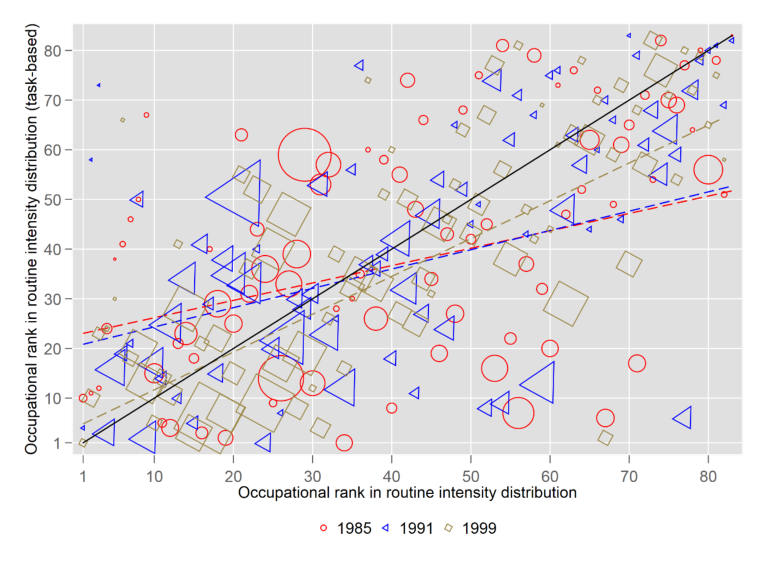

NOTE: figure/graphic rendered as an image from the PDF; its content is not machine-readable text. Caption (if any) follows as the next block.

36

Figure A1: Comparison of routine-intensity measures

*Notes: The figure compares the position of 83 occupations in the distribution of the routine-intensity measure and a taskbased measure for each of the survey years 1985, 1991 and 1999. The size of the markers is proportional to the weighted sum of observations in each occupation. The solid black line illustrates the hypothetical case in which the ranking of the occupation was identical for both measures. The dashed lines represent linear fits for each survey year derived from a weighted regression of the rank from the task-based measure on the rank of the routine-intensity measure introduced in Section 2.2. Sources: IEB, BIBB-IAB employee survey.*

Page 39

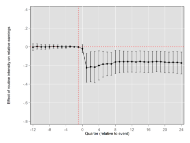

NOTE: figure/graphic rendered as an image from the PDF; its content is not machine-readable text. Caption (if any) follows as the next block.

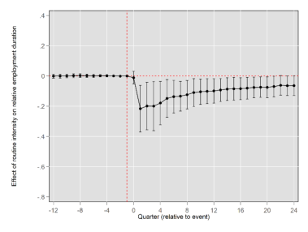

NOTE: figure/graphic rendered as an image from the PDF; its content is not machine-readable text. Caption (if any) follows as the next block.

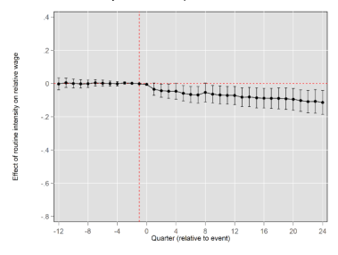

NOTE: figure/graphic rendered as an image from the PDF; its content is not machine-readable text. Caption (if any) follows as the next block.

37

Figure A2: Effect of routine-intensity on relative earnings (task-based routine-intensity measure)

*Notes: See Figure 4. A task-based measure of routine-intensity is used. Sources: IEB, BIBB-IAB employee survey.*

Figure A3: Effect of routine-intensity on relative employment duration (task-based routine-

### intensity measure)

*Notes: See* Figure 5*. A task-based measure of routine-intensity is used. Sources: IEB, BIBB-IAB employee survey.*

Figure A4: Effect of routine-intensity on relative average daily wages (task-based routine-

intensity measure)

*Notes: See* Figure 5*. A task-based measure of routine-intensity is used. Sources: IEB, BIBB-IAB employee survey.*

Page 40

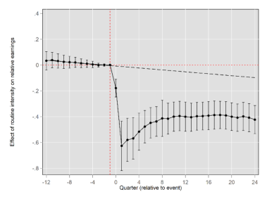

NOTE: figure/graphic rendered as an image from the PDF; its content is not machine-readable text. Caption (if any) follows as the next block.

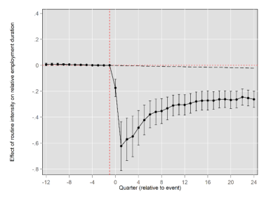

NOTE: figure/graphic rendered as an image from the PDF; its content is not machine-readable text. Caption (if any) follows as the next block.

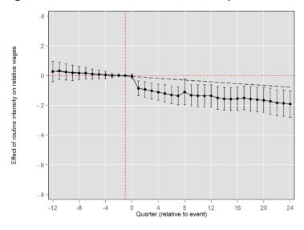

NOTE: figure/graphic rendered as an image from the PDF; its content is not machine-readable text. Caption (if any) follows as the next block.

38

Figure A5: Effect of routine-intensity on relative earnings (without adjustment)

*Notes: See Figure 4. The effects displayed in Figure 4 correspond to the vertical distance between the coefficient estimate and the black dashed line. Sources: IEB, BIBB-IAB employee survey.*

Figure A6: Effect of routine-intensity on relative employment duration (without adjustment)

*Notes: See Figure 5. The effects displayed in Figure 5 correspond to the vertical distance between the coefficient estimate and the black dashed line. Sources: IEB, BIBB-IAB employee survey.*

Figure A7: Effect of routine-intensity on relative average wage (without adjustment)

*Notes: See Figure 5. The effects displayed in Figure 5 correspond to the vertical distance between the coefficient estimate and the black dashed line. Sources: IEB, BIBB-IAB employee survey.*